# PRISMA 2009 & AMSTAR Scores in Cullis 2017: Human Consensus vs LLM - self-consistent for 3 / 5 experiments

### Score comparisons of 112 publications

| Ref. | Author & Year | PRISMA κ | PRISMA agreement | AMSTAR κ | AMSTAR agreement |
| --- | --- | --- | --- | --- | --- |
| 61 | Aikenhead 2011 | 0.7 | 0.814814814814815 | 0.721518987341772 | 0.818181818181818 |
| 62 | Al-Hozaim 2010 | 0.653104925053533 | 0.769230769230769 | 0.582278481012658 | 0.727272727272727 |
| 63 | Allen 2015 | 0.758389261744966 | 0.84 | 0.521739130434783 | 0.7 |
| 64 | Allin 2015 | 0.526315789473684 | 0.777777777777778 | 0.343283582089552 | 0.636363636363636 |
| 65 | Alzahem 2011 | 0.511627906976744 | 0.740740740740741 | 0.645161290322581 | 0.818181818181818 |
| 66 | Apelt 2013 | 0.661087866108787 | 0.777777777777778 | 0.541666666666667 | 0.727272727272727 |
| 67 | Aworanti 2014 | 0.624254473161034 | 0.740740740740741 | 0.830769230769231 | 0.9 |
| 68 | Baker 2015 | 0.604395604395604 | 0.851851851851852 | 0.241379310344828 | 0.636363636363636 |
| 69 | Berger 2012 | 0.442148760330578 | 0.6 | 0.274725274725275 | 0.454545454545455 |
| 70 | Billingham 2010 | 0.370762711864407 | 0.592592592592593 | 0.236111111111111 | 0.545454545454545 |

[output cut: 102 more lines]

### Score heatmaps (PRISMA / AMSTAR)

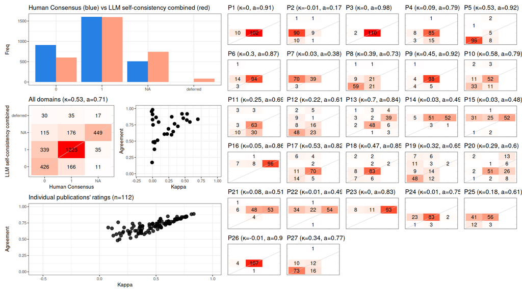

### Individual results

#### 61. Aikenhead 2011: *Effectiveness and cost-effectiveness of paediatric bariatric surgery: a systematic review*

PRISMA

|  | P1 | P2 | P3 | P4 | P5 | P6 | P7 | P8 | P9 | P10 | P11 | P12 | P13 | P14 |
| --- | --- | --- | --- | --- | --- | --- | --- | --- | --- | --- | --- | --- | --- | --- |
| Human Consensus | 1 | 0 | 1 | 1 | 0 | 1 | 1 | 1 | 1 | 0 | 1 | 0 | NA | NA |
| LLM self-consistency combined | 1 | 1 | 1 | 1 | 0 | 1 | 1 | 0 | 1 | 0 | 0 | 0 | 0 | NA |

|  | P15 | P16 | P17 | P18 | P19 | P20 | P21 | P22 | P23 | P24 | P25 | P26 | P27 |
| --- | --- | --- | --- | --- | --- | --- | --- | --- | --- | --- | --- | --- | --- |
| Human Consensus | NA | NA | 1 | 1 | 0 | NA | NA | NA | NA | 1 | 1 | 1 | 1 |
| LLM self-consistency combined | NA | NA | 1 | 1 | 0 | 1 | NA | NA | NA | 1 | 1 | 1 | 1 |

AMSTAR

|  | A1 | A2 | A3 | A4 | A5 | A6 | A7 | A8 | A9 | A10 | A11 |
| --- | --- | --- | --- | --- | --- | --- | --- | --- | --- | --- | --- |
| Human Consensus | 0 | 0 | 1 | 1 | 0 | 1 | 0 | 0 | NA | NA | 0 |
| LLM self-consistency combined | 1 | 0 | 1 | 1 | 0 | 1 | 0 | NA | NA | NA | 0 |

#### 62. Al-Hozaim 2010: *Laparoscopic-assisted anorectal pull-through for anorectal malformations: a systematic review and the need for standardization of outcome reporting*

PRISMA

|  | P1 | P2 | P3 | P4 | P5 | P6 | P7 | P8 | P9 | P10 | P11 | P12 | P13 | P14 |
| --- | --- | --- | --- | --- | --- | --- | --- | --- | --- | --- | --- | --- | --- | --- |
| Human Consensus | 1 | 0 | 1 | 0 | 0 | 1 | 0 | 0 | 1 | 1 | 1 | 0 | NA | NA |
| LLM self-consistency combined | 1 | 1 | 1 | 0 | 0 | 1 | 1 | 0 | 1 | 0 | 0 | 0 | NA | NA |

|  | P15 | P16 | P17 | P18 | P19 | P20 | P21 | P22 | P23 | P24 | P25 | P26 | P27 |
| --- | --- | --- | --- | --- | --- | --- | --- | --- | --- | --- | --- | --- | --- |
| Human Consensus | NA | NA | 0 | 1 | 0 | NA | NA | NA | NA | 0 | 1 | 1 | 0 |
| LLM self-consistency combined | NA | NA | 1 | 1 | 0 | def. | NA | NA | NA | 1 | 1 | 1 | 0 |

AMSTAR

|  | A1 | A2 | A3 | A4 | A5 | A6 | A7 | A8 | A9 | A10 | A11 |
| --- | --- | --- | --- | --- | --- | --- | --- | --- | --- | --- | --- |
| Human Consensus | 0 | 0 | 1 | 0 | 0 | 1 | 0 | 0 | NA | NA | 0 |
| LLM self-consistency combined | 1 | 0 | 1 | 0 | 1 | 1 | 0 | NA | NA | NA | 0 |

#### 63. Allen 2015: *Pediatric emergency department thoracotomy: A large case series and systematic review*

PRISMA

|  | P1 | P2 | P3 | P4 | P5 | P6 | P7 | P8 | P9 | P10 | P11 | P12 | P13 | P14 |
| --- | --- | --- | --- | --- | --- | --- | --- | --- | --- | --- | --- | --- | --- | --- |
| Human Consensus | 1 | 0 | 1 | 1 | 0 | 1 | 0 | 1 | 0 | 0 | 1 | 0 | NA | NA |
| LLM self-consistency combined | 1 | 1 | 1 | 0 | 0 | 1 | 1 | 0 | def. | 0 | 1 | 0 | NA | NA |

|  | P15 | P16 | P17 | P18 | P19 | P20 | P21 | P22 | P23 | P24 | P25 | P26 | P27 |
| --- | --- | --- | --- | --- | --- | --- | --- | --- | --- | --- | --- | --- | --- |
| Human Consensus | NA | NA | 0 | 1 | 0 | NA | NA | NA | NA | 1 | 1 | 1 | 0 |
| LLM self-consistency combined | NA | NA | 0 | 1 | 0 | def. | NA | NA | NA | 1 | 1 | 1 | 0 |

AMSTAR

|  | A1 | A2 | A3 | A4 | A5 | A6 | A7 | A8 | A9 | A10 | A11 |
| --- | --- | --- | --- | --- | --- | --- | --- | --- | --- | --- | --- |
| Human Consensus | 0 | 0 | 0 | 0 | 0 | 1 | 0 | 0 | NA | NA | 0 |
| LLM self-consistency combined | 1 | 0 | 1 | 0 | def. | 1 | 0 | NA | NA | NA | 0 |

#### 64. Allin 2015: *Challenges of Improving the Evidence Base in Smaller Surgical Specialties, as Highlighted by a Systematic Review of Gastroschisis Management*

PRISMA

|  | P1 | P2 | P3 | P4 | P5 | P6 | P7 | P8 | P9 | P10 | P11 | P12 | P13 | P14 |
| --- | --- | --- | --- | --- | --- | --- | --- | --- | --- | --- | --- | --- | --- | --- |
| Human Consensus | 1 | 0 | 1 | 1 | 1 | 1 | 1 | 0 | 1 | 1 | 1 | 1 | 1 | 1 |
| LLM self-consistency combined | 1 | 1 | 1 | 1 | 1 | 1 | 1 | 0 | 1 | 1 | 1 | 0 | 1 | NA |

|  | P15 | P16 | P17 | P18 | P19 | P20 | P21 | P22 | P23 | P24 | P25 | P26 | P27 |
| --- | --- | --- | --- | --- | --- | --- | --- | --- | --- | --- | --- | --- | --- |
| Human Consensus | 0 | NA | 1 | 1 | 0 | 1 | 1 | 0 | NA | 1 | 1 | 1 | 1 |
| LLM self-consistency combined | NA | NA | 1 | 1 | 0 | 1 | NA | NA | NA | 1 | 1 | 1 | 1 |

AMSTAR

|  | A1 | A2 | A3 | A4 | A5 | A6 | A7 | A8 | A9 | A10 | A11 |
| --- | --- | --- | --- | --- | --- | --- | --- | --- | --- | --- | --- |
| Human Consensus | 1 | 1 | 1 | 0 | 0 | 1 | 1 | 1 | 1 | 0 | 0 |
| LLM self-consistency combined | 1 | 1 | 1 | NA | 1 | 1 | 0 | NA | 1 | 0 | 0 |

#### 65. Alzahem 2011: *Laparoscopic versus open inguinal herniotomy in infants and children: a meta-analysis*

PRISMA

|  | P1 | P2 | P3 | P4 | P5 | P6 | P7 | P8 | P9 | P10 | P11 | P12 | P13 | P14 |
| --- | --- | --- | --- | --- | --- | --- | --- | --- | --- | --- | --- | --- | --- | --- |
| Human Consensus | 1 | 0 | 1 | 1 | 0 | 1 | 1 | 0 | 1 | 1 | 1 | 0 | 1 | 1 |
| LLM self-consistency combined | 1 | 1 | 1 | 1 | 0 | 1 | 1 | 0 | 1 | 1 | 1 | 1 | 1 | NA |

|  | P15 | P16 | P17 | P18 | P19 | P20 | P21 | P22 | P23 | P24 | P25 | P26 | P27 |
| --- | --- | --- | --- | --- | --- | --- | --- | --- | --- | --- | --- | --- | --- |
| Human Consensus | 0 | NA | 1 | 1 | 0 | 1 | 1 | 0 | NA | 1 | 1 | 1 | 0 |
| LLM self-consistency combined | NA | NA | 1 | 1 | 1 | 1 | NA | NA | NA | 1 | 1 | 1 | 0 |

AMSTAR

|  | A1 | A2 | A3 | A4 | A5 | A6 | A7 | A8 | A9 | A10 | A11 |
| --- | --- | --- | --- | --- | --- | --- | --- | --- | --- | --- | --- |
| Human Consensus | 0 | 1 | 1 | 1 | 0 | 1 | 1 | 1 | 1 | 0 | 0 |
| LLM self-consistency combined | 0 | 1 | 1 | 0 | 0 | 1 | 1 | 0 | 1 | 0 | 0 |

#### 66. Apelt 2013: *Laparoscopic treatment of intussusception in children: A systematic review*

PRISMA

|  | P1 | P2 | P3 | P4 | P5 | P6 | P7 | P8 | P9 | P10 | P11 | P12 | P13 | P14 |
| --- | --- | --- | --- | --- | --- | --- | --- | --- | --- | --- | --- | --- | --- | --- |
| Human Consensus | 1 | 0 | 1 | 1 | 0 | 1 | 1 | 0 | 1 | 0 | 1 | 0 | NA | NA |
| LLM self-consistency combined | 1 | 1 | 1 | 0 | 0 | 1 | 1 | 0 | 1 | 0 | 1 | 0 | 1 | NA |

|  | P15 | P16 | P17 | P18 | P19 | P20 | P21 | P22 | P23 | P24 | P25 | P26 | P27 |
| --- | --- | --- | --- | --- | --- | --- | --- | --- | --- | --- | --- | --- | --- |
| Human Consensus | NA | NA | 1 | 1 | 0 | NA | NA | NA | NA | 1 | 0 | 0 | 0 |
| LLM self-consistency combined | NA | NA | 1 | 1 | 0 | 1 | NA | NA | NA | 1 | 1 | 1 | 0 |

AMSTAR

|  | A1 | A2 | A3 | A4 | A5 | A6 | A7 | A8 | A9 | A10 | A11 |
| --- | --- | --- | --- | --- | --- | --- | --- | --- | --- | --- | --- |
| Human Consensus | 0 | 0 | 0 | 0 | 0 | 1 | 0 | 0 | NA | NA | 0 |
| LLM self-consistency combined | 1 | 0 | 1 | 0 | 0 | 1 | 0 | NA | NA | NA | 0 |

#### 67. Aworanti 2014: *Management of Recurrent Tracheoesophageal Fistulas: A Systematic Review*

PRISMA

|  | P1 | P2 | P3 | P4 | P5 | P6 | P7 | P8 | P9 | P10 | P11 | P12 | P13 | P14 |
| --- | --- | --- | --- | --- | --- | --- | --- | --- | --- | --- | --- | --- | --- | --- |
| Human Consensus | 1 | 0 | 1 | 0 | 0 | 1 | 1 | 0 | 0 | 0 | 1 | 0 | NA | NA |
| LLM self-consistency combined | 1 | 1 | 1 | 1 | 0 | 1 | 1 | 0 | 1 | 0 | 1 | 0 | NA | NA |

|  | P15 | P16 | P17 | P18 | P19 | P20 | P21 | P22 | P23 | P24 | P25 | P26 | P27 |
| --- | --- | --- | --- | --- | --- | --- | --- | --- | --- | --- | --- | --- | --- |
| Human Consensus | NA | NA | 0 | 1 | 0 | NA | NA | NA | NA | 0 | 0 | 1 | 0 |
| LLM self-consistency combined | NA | NA | 1 | 1 | 0 | 1 | NA | NA | NA | 1 | 1 | 1 | 0 |

AMSTAR

|  | A1 | A2 | A3 | A4 | A5 | A6 | A7 | A8 | A9 | A10 | A11 |
| --- | --- | --- | --- | --- | --- | --- | --- | --- | --- | --- | --- |
| Human Consensus | 0 | 0 | 1 | 0 | 0 | 1 | 0 | 0 | NA | NA | 0 |
| LLM self-consistency combined | 1 | 0 | 1 | 0 | 0 | 1 | 0 | def. | NA | NA | 0 |

#### 68. Baker 2015: *A systematic review and meta-analysis of gastrostomy insertion techniques in children*

PRISMA

|  | P1 | P2 | P3 | P4 | P5 | P6 | P7 | P8 | P9 | P10 | P11 | P12 | P13 | P14 |
| --- | --- | --- | --- | --- | --- | --- | --- | --- | --- | --- | --- | --- | --- | --- |
| Human Consensus | 1 | 0 | 1 | 1 | 0 | 1 | 1 | 1 | 1 | 1 | 1 | 1 | 1 | 1 |
| LLM self-consistency combined | 1 | 1 | 1 | 1 | 0 | 1 | 1 | 1 | 1 | 1 | 1 | 1 | 1 | NA |

|  | P15 | P16 | P17 | P18 | P19 | P20 | P21 | P22 | P23 | P24 | P25 | P26 | P27 |
| --- | --- | --- | --- | --- | --- | --- | --- | --- | --- | --- | --- | --- | --- |
| Human Consensus | 1 | NA | 1 | 1 | 1 | 1 | 1 | 1 | NA | 1 | 1 | 1 | 0 |
| LLM self-consistency combined | NA | NA | 1 | 1 | 1 | 1 | 1 | NA | NA | 1 | 1 | 1 | 0 |

AMSTAR

|  | A1 | A2 | A3 | A4 | A5 | A6 | A7 | A8 | A9 | A10 | A11 |
| --- | --- | --- | --- | --- | --- | --- | --- | --- | --- | --- | --- |
| Human Consensus | 0 | 1 | 0 | 0 | 0 | 1 | 1 | 1 | 1 | 1 | 0 |
| LLM self-consistency combined | 1 | 1 | 1 | 0 | 1 | 1 | 1 | 0 | 1 | 1 | 0 |

#### 69. Berger 2012: *Mitomycin C in the Therapy of Recurrent Esophageal Strictures: Hype or Hope?*

PRISMA

|  | P1 | P2 | P3 | P4 | P5 | P6 | P7 | P8 | P9 | P10 | P11 | P12 | P13 | P14 |
| --- | --- | --- | --- | --- | --- | --- | --- | --- | --- | --- | --- | --- | --- | --- |
| Human Consensus | 0 | 0 | 1 | 0 | 0 | 1 | 0 | 0 | 1 | 0 | 0 | 0 | NA | NA |
| LLM self-consistency combined | 1 | 1 | 1 | 1 | 0 | 1 | 1 | 0 | 1 | def. | def. | NA | NA | NA |

|  | P15 | P16 | P17 | P18 | P19 | P20 | P21 | P22 | P23 | P24 | P25 | P26 | P27 |
| --- | --- | --- | --- | --- | --- | --- | --- | --- | --- | --- | --- | --- | --- |
| Human Consensus | NA | NA | 0 | 1 | 0 | NA | NA | NA | NA | 0 | 0 | 1 | 1 |
| LLM self-consistency combined | NA | NA | 1 | 1 | NA | NA | NA | NA | NA | 1 | 1 | 1 | 0 |

AMSTAR

|  | A1 | A2 | A3 | A4 | A5 | A6 | A7 | A8 | A9 | A10 | A11 |
| --- | --- | --- | --- | --- | --- | --- | --- | --- | --- | --- | --- |
| Human Consensus | 0 | 0 | 0 | 0 | 0 | 1 | 0 | 0 | NA | NA | 0 |
| LLM self-consistency combined | 0 | 1 | 1 | NA | 1 | 1 | 0 | NA | NA | NA | NA |

#### 70. Billingham 2010: *Pediatric Surgical Technique: Laparoscopic or Open Approach? A systematic Review and Meta-Analysis*

PRISMA

|  | P1 | P2 | P3 | P4 | P5 | P6 | P7 | P8 | P9 | P10 | P11 | P12 | P13 | P14 |
| --- | --- | --- | --- | --- | --- | --- | --- | --- | --- | --- | --- | --- | --- | --- |
| Human Consensus | 1 | 0 | 1 | 1 | 0 | 1 | 0 | 0 | 1 | 0 | 1 | 0 | 0 | 0 |
| LLM self-consistency combined | 1 | 1 | 1 | 1 | 0 | 1 | 1 | 0 | 1 | 0 | 0 | 0 | 1 | NA |

|  | P15 | P16 | P17 | P18 | P19 | P20 | P21 | P22 | P23 | P24 | P25 | P26 | P27 |
| --- | --- | --- | --- | --- | --- | --- | --- | --- | --- | --- | --- | --- | --- |
| Human Consensus | 0 | NA | 0 | 1 | 0 | 1 | 1 | 0 | NA | 0 | 0 | 1 | 0 |
| LLM self-consistency combined | NA | NA | 0 | 1 | 0 | 1 | NA | NA | NA | 1 | 1 | 1 | 1 |

AMSTAR

|  | A1 | A2 | A3 | A4 | A5 | A6 | A7 | A8 | A9 | A10 | A11 |
| --- | --- | --- | --- | --- | --- | --- | --- | --- | --- | --- | --- |
| Human Consensus | 0 | 0 | 1 | 0 | 0 | 1 | 1 | 1 | 1 | 0 | 0 |
| LLM self-consistency combined | 1 | 0 | 1 | 0 | 0 | 1 | 1 | 0 | NA | NA | 1 |

#### 71. Black 2013: *Bariatric surgery for obese children and adolescents: a systematic review and meta-analysis*

PRISMA

|  | P1 | P2 | P3 | P4 | P5 | P6 | P7 | P8 | P9 | P10 | P11 | P12 | P13 | P14 |
| --- | --- | --- | --- | --- | --- | --- | --- | --- | --- | --- | --- | --- | --- | --- |
| Human Consensus | 1 | 0 | 1 | 1 | 0 | 1 | 0 | 1 | 1 | 1 | 1 | 1 | 0 | 1 |
| LLM self-consistency combined | 1 | 1 | 1 | 1 | 0 | 1 | 1 | 1 | 1 | 1 | 1 | 0 | 1 | 1 |

|  | P15 | P16 | P17 | P18 | P19 | P20 | P21 | P22 | P23 | P24 | P25 | P26 | P27 |
| --- | --- | --- | --- | --- | --- | --- | --- | --- | --- | --- | --- | --- | --- |
| Human Consensus | 1 | NA | 1 | 1 | 0 | 1 | 1 | 0 | NA | 1 | 1 | 1 | 0 |
| LLM self-consistency combined | 0 | NA | 1 | 1 | 0 | 1 | 1 | NA | NA | 1 | 1 | 1 | 0 |

AMSTAR

|  | A1 | A2 | A3 | A4 | A5 | A6 | A7 | A8 | A9 | A10 | A11 |
| --- | --- | --- | --- | --- | --- | --- | --- | --- | --- | --- | --- |
| Human Consensus | 0 | 1 | 1 | 0 | 0 | 1 | 0 | 0 | 1 | 0 | 0 |
| LLM self-consistency combined | 1 | def. | 1 | def. | 1 | 1 | 0 | NA | 1 | 1 | 0 |

#### 72. Borruto 2010: *Laparoscopic vs open varicocelectomy in children and adolescents: review of the recent literature and meta-analysis*

PRISMA

|  | P1 | P2 | P3 | P4 | P5 | P6 | P7 | P8 | P9 | P10 | P11 | P12 | P13 | P14 |
| --- | --- | --- | --- | --- | --- | --- | --- | --- | --- | --- | --- | --- | --- | --- |
| Human Consensus | 1 | 0 | 1 | 1 | 0 | 1 | 0 | 0 | 1 | 0 | 1 | 0 | 1 | 0 |
| LLM self-consistency combined | 1 | 0 | 1 | 0 | 0 | 1 | 1 | 0 | 1 | 0 | 1 | 0 | NA | NA |

|  | P15 | P16 | P17 | P18 | P19 | P20 | P21 | P22 | P23 | P24 | P25 | P26 | P27 |
| --- | --- | --- | --- | --- | --- | --- | --- | --- | --- | --- | --- | --- | --- |
| Human Consensus | 0 | NA | 0 | 0 | 0 | 1 | 0 | 0 | NA | 1 | 0 | 1 | 0 |
| LLM self-consistency combined | NA | NA | 0 | 0 | 0 | 1 | def. | NA | NA | 0 | 0 | 0 | 0 |

AMSTAR

|  | A1 | A2 | A3 | A4 | A5 | A6 | A7 | A8 | A9 | A10 | A11 |
| --- | --- | --- | --- | --- | --- | --- | --- | --- | --- | --- | --- |
| Human Consensus | 0 | 0 | 0 | 0 | 0 | 0 | 0 | 0 | 0 | 0 | 0 |
| LLM self-consistency combined | 1 | 0 | 1 | 0 | 0 | 1 | 0 | NA | NA | NA | 0 |

#### 73. Castagnetti 2010: *Surgical Management of Primary Severe Hypospadias in Children: Systematic 20-Year Review*

PRISMA

|  | P1 | P2 | P3 | P4 | P5 | P6 | P7 | P8 | P9 | P10 | P11 | P12 | P13 | P14 |
| --- | --- | --- | --- | --- | --- | --- | --- | --- | --- | --- | --- | --- | --- | --- |
| Human Consensus | 1 | 0 | 1 | 0 | 0 | 0 | 0 | 1 | 1 | 0 | 1 | 0 | NA | NA |
| LLM self-consistency combined | 1 | 1 | 1 | 1 | 0 | 1 | 1 | 0 | 1 | 0 | 0 | 0 | NA | NA |

|  | P15 | P16 | P17 | P18 | P19 | P20 | P21 | P22 | P23 | P24 | P25 | P26 | P27 |
| --- | --- | --- | --- | --- | --- | --- | --- | --- | --- | --- | --- | --- | --- |
| Human Consensus | NA | NA | 0 | 0 | 0 | NA | NA | NA | NA | 1 | 0 | 1 | 0 |
| LLM self-consistency combined | NA | NA | def. | 0 | 0 | 1 | NA | NA | NA | 1 | 1 | 1 | 0 |

AMSTAR

|  | A1 | A2 | A3 | A4 | A5 | A6 | A7 | A8 | A9 | A10 | A11 |
| --- | --- | --- | --- | --- | --- | --- | --- | --- | --- | --- | --- |
| Human Consensus | 0 | 0 | 0 | 0 | 0 | 0 | 1 | 1 | NA | NA | 0 |
| LLM self-consistency combined | 1 | 0 | 1 | 0 | 0 | 1 | 0 | 0 | NA | NA | 0 |

#### 74. Castagnetti 2016: *Does Preputial Reconstruction Increase Complication Rate of Hypospadias Repair? 20-Year Systematic Review and Meta-Analysis*

PRISMA

|  | P1 | P2 | P3 | P4 | P5 | P6 | P7 | P8 | P9 | P10 | P11 | P12 | P13 | P14 |
| --- | --- | --- | --- | --- | --- | --- | --- | --- | --- | --- | --- | --- | --- | --- |
| Human Consensus | 1 | 0 | 1 | 1 | 0 | 1 | 0 | 0 | 1 | 0 | 1 | 1 | 1 | 1 |
| LLM self-consistency combined | 1 | 1 | 1 | 1 | 0 | 1 | 1 | 0 | 1 | 0 | 1 | 0 | 1 | NA |

|  | P15 | P16 | P17 | P18 | P19 | P20 | P21 | P22 | P23 | P24 | P25 | P26 | P27 |
| --- | --- | --- | --- | --- | --- | --- | --- | --- | --- | --- | --- | --- | --- |
| Human Consensus | 1 | NA | 1 | 1 | 1 | 1 | 1 | 1 | NA | 0 | 1 | 1 | 0 |
| LLM self-consistency combined | NA | NA | 1 | 1 | 0 | 1 | NA | NA | NA | 1 | 1 | 1 | 1 |

AMSTAR

|  | A1 | A2 | A3 | A4 | A5 | A6 | A7 | A8 | A9 | A10 | A11 |
| --- | --- | --- | --- | --- | --- | --- | --- | --- | --- | --- | --- |
| Human Consensus | 0 | 0 | 0 | 0 | 0 | 1 | 1 | 1 | 1 | 1 | 1 |
| LLM self-consistency combined | 1 | 0 | 1 | 0 | 1 | 1 | 0 | 0 | 1 | 0 | 0 |

#### 75. Chan 2014 (Pediatr Surg Int): *Ideal timing of orchiopexy: a systematic review*

PRISMA

|  | P1 | P2 | P3 | P4 | P5 | P6 | P7 | P8 | P9 | P10 | P11 | P12 | P13 | P14 |
| --- | --- | --- | --- | --- | --- | --- | --- | --- | --- | --- | --- | --- | --- | --- |
| Human Consensus | 1 | 0 | 1 | 1 | 0 | 1 | 0 | 1 | 1 | 1 | 1 | 1 | NA | NA |
| LLM self-consistency combined | 1 | 1 | 1 | 0 | 0 | 1 | 1 | 0 | 1 | 1 | 0 | 1 | NA | NA |

|  | P15 | P16 | P17 | P18 | P19 | P20 | P21 | P22 | P23 | P24 | P25 | P26 | P27 |
| --- | --- | --- | --- | --- | --- | --- | --- | --- | --- | --- | --- | --- | --- |
| Human Consensus | NA | NA | 1 | 1 | 0 | NA | NA | NA | NA | 1 | 1 | 1 | 0 |
| LLM self-consistency combined | NA | NA | 1 | 1 | 1 | 1 | NA | NA | NA | 1 | 1 | 1 | 0 |

AMSTAR

|  | A1 | A2 | A3 | A4 | A5 | A6 | A7 | A8 | A9 | A10 | A11 |
| --- | --- | --- | --- | --- | --- | --- | --- | --- | --- | --- | --- |
| Human Consensus | 0 | 1 | 1 | 0 | 0 | 1 | 1 | 1 | NA | NA | 0 |
| LLM self-consistency combined | def. | 1 | 1 | 0 | def. | 1 | 1 | 1 | NA | 0 | 0 |

#### 76. Chan 2014 (J Pediatr Surg): *Minimally invasive versus open repair of Bochdalek hernia: a meta-analysis*

PRISMA

|  | P1 | P2 | P3 | P4 | P5 | P6 | P7 | P8 | P9 | P10 | P11 | P12 | P13 | P14 |
| --- | --- | --- | --- | --- | --- | --- | --- | --- | --- | --- | --- | --- | --- | --- |
| Human Consensus | 1 | 0 | 1 | 1 | 0 | 1 | 0 | 0 | 1 | 0 | 1 | 1 | 1 | 1 |
| LLM self-consistency combined | 1 | 1 | 1 | 1 | 0 | 1 | 1 | 1 | 1 | 1 | 1 | 1 | 1 | NA |

|  | P15 | P16 | P17 | P18 | P19 | P20 | P21 | P22 | P23 | P24 | P25 | P26 | P27 |
| --- | --- | --- | --- | --- | --- | --- | --- | --- | --- | --- | --- | --- | --- |
| Human Consensus | 1 | NA | 1 | 1 | 1 | 1 | 1 | 1 | NA | 1 | 1 | 1 | 0 |
| LLM self-consistency combined | NA | NA | 1 | 1 | def. | 1 | NA | NA | NA | 1 | 1 | 1 | 0 |

AMSTAR

|  | A1 | A2 | A3 | A4 | A5 | A6 | A7 | A8 | A9 | A10 | A11 |
| --- | --- | --- | --- | --- | --- | --- | --- | --- | --- | --- | --- |
| Human Consensus | 0 | 0 | 1 | 0 | 0 | 1 | 1 | 1 | 1 | 1 | 0 |
| LLM self-consistency combined | 1 | 1 | 1 | NA | 1 | 1 | 1 | 1 | 1 | 1 | 0 |

#### 77. Chang 2015: *Comparing the efficacy and safety between robotic-assisted versus open pyeloplasty in children: a systemic review and meta-analysis*

PRISMA

|  | P1 | P2 | P3 | P4 | P5 | P6 | P7 | P8 | P9 | P10 | P11 | P12 | P13 | P14 |
| --- | --- | --- | --- | --- | --- | --- | --- | --- | --- | --- | --- | --- | --- | --- |
| Human Consensus | 1 | 0 | 1 | 1 | 0 | 1 | 0 | 0 | 1 | 1 | 1 | 1 | 1 | 1 |
| LLM self-consistency combined | 1 | 1 | 1 | 1 | 0 | 1 | 1 | 0 | 1 | 1 | 0 | 0 | def. | NA |

|  | P15 | P16 | P17 | P18 | P19 | P20 | P21 | P22 | P23 | P24 | P25 | P26 | P27 |
| --- | --- | --- | --- | --- | --- | --- | --- | --- | --- | --- | --- | --- | --- |
| Human Consensus | 0 | NA | 1 | 1 | 0 | 1 | 1 | 1 | NA | 0 | 0 | 1 | 1 |
| LLM self-consistency combined | NA | NA | 1 | 1 | 0 | 1 | NA | NA | NA | 1 | 1 | 1 | 0 |

AMSTAR

|  | A1 | A2 | A3 | A4 | A5 | A6 | A7 | A8 | A9 | A10 | A11 |
| --- | --- | --- | --- | --- | --- | --- | --- | --- | --- | --- | --- |
| Human Consensus | 0 | 1 | 0 | 0 | 0 | 1 | 0 | 0 | 1 | 1 | 0 |
| LLM self-consistency combined | 1 | 1 | 1 | 0 | 0 | 1 | 0 | NA | 1 | 0 | 0 |

#### 78. Chen 2013: *Transanal endorectal pull-through versus transabdominal approach for Hirschsprung’s disease: A systematic review and meta-analysis*

PRISMA

|  | P1 | P2 | P3 | P4 | P5 | P6 | P7 | P8 | P9 | P10 | P11 | P12 | P13 | P14 |
| --- | --- | --- | --- | --- | --- | --- | --- | --- | --- | --- | --- | --- | --- | --- |
| Human Consensus | 1 | 0 | 1 | 1 | 0 | 1 | 0 | 0 | 1 | 1 | 1 | 0 | 1 | 1 |
| LLM self-consistency combined | 1 | 1 | 1 | 1 | 0 | 1 | 1 | 0 | 1 | 1 | 1 | 0 | 1 | NA |

|  | P15 | P16 | P17 | P18 | P19 | P20 | P21 | P22 | P23 | P24 | P25 | P26 | P27 |
| --- | --- | --- | --- | --- | --- | --- | --- | --- | --- | --- | --- | --- | --- |
| Human Consensus | 0 | NA | 1 | 1 | 0 | 1 | 1 | 0 | NA | 1 | 1 | 1 | 0 |
| LLM self-consistency combined | NA | NA | 1 | 1 | 0 | 1 | NA | NA | NA | 1 | 1 | 1 | 0 |

AMSTAR

|  | A1 | A2 | A3 | A4 | A5 | A6 | A7 | A8 | A9 | A10 | A11 |
| --- | --- | --- | --- | --- | --- | --- | --- | --- | --- | --- | --- |
| Human Consensus | 0 | 0 | 1 | 0 | 0 | 1 | 0 | 0 | 1 | 0 | 0 |
| LLM self-consistency combined | 0 | 1 | 1 | NA | 1 | 1 | 0 | NA | 1 | NA | def. |

#### 79. Corbett 2015: *Outcomes of endopyelotomy for pelviureteric junction obstruction in the paediatric population: A systematic review*

PRISMA

|  | P1 | P2 | P3 | P4 | P5 | P6 | P7 | P8 | P9 | P10 | P11 | P12 | P13 | P14 |
| --- | --- | --- | --- | --- | --- | --- | --- | --- | --- | --- | --- | --- | --- | --- |
| Human Consensus | 1 | 1 | 1 | 1 | 0 | 1 | 1 | 0 | 1 | 1 | 0 | 0 | NA | NA |
| LLM self-consistency combined | 1 | 0 | 1 | 0 | 0 | 1 | 1 | 0 | 1 | 1 | 0 | NA | NA | NA |

|  | P15 | P16 | P17 | P18 | P19 | P20 | P21 | P22 | P23 | P24 | P25 | P26 | P27 |
| --- | --- | --- | --- | --- | --- | --- | --- | --- | --- | --- | --- | --- | --- |
| Human Consensus | NA | NA | 1 | 1 | 0 | NA | NA | NA | NA | 0 | 1 | 1 | 1 |
| LLM self-consistency combined | NA | NA | 1 | 1 | NA | 1 | NA | NA | NA | 1 | 1 | 1 | 0 |

AMSTAR

|  | A1 | A2 | A3 | A4 | A5 | A6 | A7 | A8 | A9 | A10 | A11 |
| --- | --- | --- | --- | --- | --- | --- | --- | --- | --- | --- | --- |
| Human Consensus | 0 | 1 | 0 | 0 | 0 | 1 | 0 | 0 | NA | NA | 0 |
| LLM self-consistency combined | 0 | 1 | 1 | 0 | 1 | 1 | 0 | 0 | NA | NA | 0 |

#### 80. Cullis 2016: *Is Screening of Intestinal Foregut Anatomy in Heterotaxy Patients Really Necessary?*

PRISMA

|  | P1 | P2 | P3 | P4 | P5 | P6 | P7 | P8 | P9 | P10 | P11 | P12 | P13 | P14 |
| --- | --- | --- | --- | --- | --- | --- | --- | --- | --- | --- | --- | --- | --- | --- |
| Human Consensus | 1 | 0 | 1 | 1 | 0 | 1 | 1 | 1 | 1 | 1 | 1 | 1 | NA | NA |
| LLM self-consistency combined | 1 | 1 | 1 | 1 | 0 | 1 | 1 | 1 | 1 | 1 | 0 | 0 | NA | NA |

|  | P15 | P16 | P17 | P18 | P19 | P20 | P21 | P22 | P23 | P24 | P25 | P26 | P27 |
| --- | --- | --- | --- | --- | --- | --- | --- | --- | --- | --- | --- | --- | --- |
| Human Consensus | NA | NA | 1 | 1 | 1 | NA | NA | NA | NA | 1 | 1 | 1 | 1 |
| LLM self-consistency combined | NA | NA | 0 | 1 | 0 | def. | NA | NA | NA | 1 | 1 | 1 | 0 |

AMSTAR

|  | A1 | A2 | A3 | A4 | A5 | A6 | A7 | A8 | A9 | A10 | A11 |
| --- | --- | --- | --- | --- | --- | --- | --- | --- | --- | --- | --- |
| Human Consensus | 1 | 1 | 1 | 1 | 0 | 1 | 1 | 1 | NA | NA | 0 |
| LLM self-consistency combined | 1 | 1 | 1 | 0 | 0 | 1 | 1 | 1 | NA | 0 | 0 |

#### 81. Cundy 2014 (BJU Int): *Meta-analysis of robot-assisted vs conventional laparoscopic and open pyeloplasty in children*

PRISMA

|  | P1 | P2 | P3 | P4 | P5 | P6 | P7 | P8 | P9 | P10 | P11 | P12 | P13 | P14 |
| --- | --- | --- | --- | --- | --- | --- | --- | --- | --- | --- | --- | --- | --- | --- |
| Human Consensus | 1 | 0 | 1 | 1 | 1 | 1 | 0 | 1 | 1 | 1 | 1 | 1 | 1 | 1 |
| LLM self-consistency combined | 1 | 1 | 1 | 1 | 1 | 1 | 1 | 0 | 1 | 1 | 0 | 1 | 1 | NA |

|  | P15 | P16 | P17 | P18 | P19 | P20 | P21 | P22 | P23 | P24 | P25 | P26 | P27 |
| --- | --- | --- | --- | --- | --- | --- | --- | --- | --- | --- | --- | --- | --- |
| Human Consensus | 1 | 1 | 1 | 1 | 1 | 1 | 1 | 1 | 1 | 1 | 1 | 1 | 0 |
| LLM self-consistency combined | def. | NA | 1 | 1 | 1 | 1 | NA | def. | NA | 1 | 1 | 1 | 0 |

AMSTAR

|  | A1 | A2 | A3 | A4 | A5 | A6 | A7 | A8 | A9 | A10 | A11 |
| --- | --- | --- | --- | --- | --- | --- | --- | --- | --- | --- | --- |
| Human Consensus | 1 | 1 | 1 | 1 | 0 | 1 | 1 | 1 | 1 | 1 | 0 |
| LLM self-consistency combined | 1 | 1 | 1 | 0 | 1 | 1 | 1 | 1 | 1 | 1 | 0 |

#### 82. Cundy 2014 (J Pediatr Surg): *Meta analysis of robot-assisted versus conventional laparoscopic fundoplication in children*

PRISMA

|  | P1 | P2 | P3 | P4 | P5 | P6 | P7 | P8 | P9 | P10 | P11 | P12 | P13 | P14 |
| --- | --- | --- | --- | --- | --- | --- | --- | --- | --- | --- | --- | --- | --- | --- |
| Human Consensus | 1 | 0 | 1 | 1 | 1 | 1 | 0 | 1 | 1 | 1 | 1 | 1 | 1 | 1 |
| LLM self-consistency combined | 1 | 1 | 1 | 1 | 0 | 1 | 1 | 1 | 1 | 1 | 1 | 1 | 1 | NA |

|  | P15 | P16 | P17 | P18 | P19 | P20 | P21 | P22 | P23 | P24 | P25 | P26 | P27 |
| --- | --- | --- | --- | --- | --- | --- | --- | --- | --- | --- | --- | --- | --- |
| Human Consensus | 1 | NA | 1 | 1 | 1 | 1 | 1 | 1 | NA | 1 | 1 | 1 | 0 |
| LLM self-consistency combined | NA | NA | 1 | 1 | 1 | 1 | NA | NA | NA | 1 | 1 | 1 | 0 |

AMSTAR

|  | A1 | A2 | A3 | A4 | A5 | A6 | A7 | A8 | A9 | A10 | A11 |
| --- | --- | --- | --- | --- | --- | --- | --- | --- | --- | --- | --- |
| Human Consensus | 1 | 1 | 1 | 1 | 0 | 1 | 1 | 1 | NA | NA | 0 |
| LLM self-consistency combined | 1 | 1 | 1 | 0 | 1 | 1 | 0 | 1 | NA | NA | 0 |

#### 83. Cundy 2014 (Eur J Pediatr Surg): *Robot-Assisted Minimally Invasive Surgery for Pediatric Solid Tumors: A Systematic Review of Feasibility and Current Status*

PRISMA

|  | P1 | P2 | P3 | P4 | P5 | P6 | P7 | P8 | P9 | P10 | P11 | P12 | P13 | P14 |
| --- | --- | --- | --- | --- | --- | --- | --- | --- | --- | --- | --- | --- | --- | --- |
| Human Consensus | 1 | 0 | 1 | 1 | 1 | 1 | 0 | 1 | 1 | 0 | 1 | 0 | NA | NA |
| LLM self-consistency combined | 1 | 1 | 1 | 1 | 1 | 1 | 1 | 0 | 1 | 1 | 1 | 1 | 1 | NA |

|  | P15 | P16 | P17 | P18 | P19 | P20 | P21 | P22 | P23 | P24 | P25 | P26 | P27 |
| --- | --- | --- | --- | --- | --- | --- | --- | --- | --- | --- | --- | --- | --- |
| Human Consensus | NA | NA | 1 | 1 | 0 | NA | NA | NA | NA | 1 | 0 | 1 | 0 |
| LLM self-consistency combined | NA | NA | 1 | 1 | 1 | 1 | NA | NA | NA | 1 | 1 | 1 | 0 |

AMSTAR

|  | A1 | A2 | A3 | A4 | A5 | A6 | A7 | A8 | A9 | A10 | A11 |
| --- | --- | --- | --- | --- | --- | --- | --- | --- | --- | --- | --- |
| Human Consensus | 1 | 0 | 1 | 1 | 0 | 1 | 0 | 1 | NA | 0 | 0 |
| LLM self-consistency combined | 1 | 1 | 1 | 0 | 1 | 1 | 1 | 0 | def. | 0 | 0 |

#### 84. Ding 2013: *Single-incision versus conventional three-incision laparoscopic appendicectomy for appendicitis: A systematic review and meta-analysis*

PRISMA

|  | P1 | P2 | P3 | P4 | P5 | P6 | P7 | P8 | P9 | P10 | P11 | P12 | P13 | P14 |
| --- | --- | --- | --- | --- | --- | --- | --- | --- | --- | --- | --- | --- | --- | --- |
| Human Consensus | 1 | 0 | 1 | 1 | 0 | 1 | 0 | 1 | 1 | 1 | 1 | 1 | 1 | 1 |
| LLM self-consistency combined | 1 | 1 | 1 | 1 | 0 | 1 | 1 | 0 | 1 | 0 | 0 | def. | 1 | NA |

|  | P15 | P16 | P17 | P18 | P19 | P20 | P21 | P22 | P23 | P24 | P25 | P26 | P27 |
| --- | --- | --- | --- | --- | --- | --- | --- | --- | --- | --- | --- | --- | --- |
| Human Consensus | 1 | NA | 1 | 1 | 1 | 1 | 1 | 1 | NA | 1 | 1 | 1 | 1 |
| LLM self-consistency combined | NA | NA | 1 | 1 | def. | 1 | NA | NA | NA | 1 | 1 | 1 | 0 |

AMSTAR

|  | A1 | A2 | A3 | A4 | A5 | A6 | A7 | A8 | A9 | A10 | A11 |
| --- | --- | --- | --- | --- | --- | --- | --- | --- | --- | --- | --- |
| Human Consensus | 0 | 0 | 0 | 0 | 0 | 1 | 1 | 1 | 1 | 1 | 0 |
| LLM self-consistency combined | 1 | 0 | 1 | NA | 1 | 1 | 1 | 0 | 1 | 1 | 0 |

#### 85. Dingemann 2014: *Thoracoscopic Procedures in Pediatric Surgery: What is the Evidence?*

PRISMA

|  | P1 | P2 | P3 | P4 | P5 | P6 | P7 | P8 | P9 | P10 | P11 | P12 | P13 | P14 |
| --- | --- | --- | --- | --- | --- | --- | --- | --- | --- | --- | --- | --- | --- | --- |
| Human Consensus | 1 | 0 | 1 | 1 | 0 | 0 | 1 | 0 | 1 | 0 | 0 | 0 | NA | NA |
| LLM self-consistency combined | 1 | 0 | 1 | 1 | 0 | 1 | 1 | 0 | 1 | 0 | 1 | def. | NA | NA |

|  | P15 | P16 | P17 | P18 | P19 | P20 | P21 | P22 | P23 | P24 | P25 | P26 | P27 |
| --- | --- | --- | --- | --- | --- | --- | --- | --- | --- | --- | --- | --- | --- |
| Human Consensus | NA | NA | 0 | 1 | 0 | NA | NA | NA | NA | 1 | 0 | 1 | 0 |
| LLM self-consistency combined | NA | NA | 0 | 1 | def. | 1 | NA | NA | NA | 0 | 0 | 1 | 0 |

AMSTAR

|  | A1 | A2 | A3 | A4 | A5 | A6 | A7 | A8 | A9 | A10 | A11 |
| --- | --- | --- | --- | --- | --- | --- | --- | --- | --- | --- | --- |
| Human Consensus | 0 | 0 | 0 | 0 | 0 | 1 | 1 | 1 | NA | NA | 0 |
| LLM self-consistency combined | 1 | 0 | 0 | 0 | 0 | 0 | 1 | 0 | NA | NA | 0 |

#### 86. Dingemann 2013: *Systematic Review of Level 1 Evidence for Laparoscopic Pediatric Surgery: Do Our Procedures Comply with the Requirements of Evidence-Based Medicine?*

PRISMA

|  | P1 | P2 | P3 | P4 | P5 | P6 | P7 | P8 | P9 | P10 | P11 | P12 | P13 | P14 |
| --- | --- | --- | --- | --- | --- | --- | --- | --- | --- | --- | --- | --- | --- | --- |
| Human Consensus | 1 | 0 | 1 | 1 | 0 | 0 | 0 | 0 | 1 | 0 | 0 | 0 | NA | NA |
| LLM self-consistency combined | 1 | 1 | 1 | 1 | 0 | 1 | 1 | 0 | 1 | def. | def. | NA | NA | NA |

|  | P15 | P16 | P17 | P18 | P19 | P20 | P21 | P22 | P23 | P24 | P25 | P26 | P27 |
| --- | --- | --- | --- | --- | --- | --- | --- | --- | --- | --- | --- | --- | --- |
| Human Consensus | NA | NA | 0 | 1 | 0 | NA | NA | NA | NA | 1 | 0 | 1 | 0 |
| LLM self-consistency combined | NA | NA | 1 | 1 | NA | 1 | NA | NA | NA | 1 | 1 | 1 | 0 |

AMSTAR

|  | A1 | A2 | A3 | A4 | A5 | A6 | A7 | A8 | A9 | A10 | A11 |
| --- | --- | --- | --- | --- | --- | --- | --- | --- | --- | --- | --- |
| Human Consensus | 0 | 0 | 0 | 0 | 0 | 1 | 1 | 1 | NA | NA | 0 |
| LLM self-consistency combined | 1 | 0 | 1 | 0 | 0 | 1 | 0 | NA | NA | NA | def. |

#### 87. Ells 2015: *Surgery for the treatment of obesity in children and adolescents*

PRISMA

|  | P1 | P2 | P3 | P4 | P5 | P6 | P7 | P8 | P9 | P10 | P11 | P12 | P13 | P14 |
| --- | --- | --- | --- | --- | --- | --- | --- | --- | --- | --- | --- | --- | --- | --- |
| Human Consensus | 0 | 1 | 1 | 1 | 1 | 1 | 1 | 1 | 1 | 1 | 1 | 1 | NA | NA |
| LLM self-consistency combined | 1 | def. | 1 | 1 | 0 | 1 | 1 | 1 | 1 | 1 | 1 | 1 | 1 | NA |

|  | P15 | P16 | P17 | P18 | P19 | P20 | P21 | P22 | P23 | P24 | P25 | P26 | P27 |
| --- | --- | --- | --- | --- | --- | --- | --- | --- | --- | --- | --- | --- | --- |
| Human Consensus | NA | NA | 1 | 1 | 1 | NA | NA | NA | NA | 1 | 1 | 1 | 0 |
| LLM self-consistency combined | NA | NA | 1 | 1 | 1 | 1 | NA | NA | NA | 1 | 1 | 1 | 0 |

AMSTAR

|  | A1 | A2 | A3 | A4 | A5 | A6 | A7 | A8 | A9 | A10 | A11 |
| --- | --- | --- | --- | --- | --- | --- | --- | --- | --- | --- | --- |
| Human Consensus | 1 | 1 | 1 | 1 | 1 | 1 | 1 | 1 | NA | NA | 0 |
| LLM self-consistency combined | 1 | NA | 1 | NA | NA | 1 | NA | NA | NA | NA | def. |

#### 88. Elyas 2010: *Is Staging Beneficial for Fowler-Stephens Orchiopexy? A Systematic Review*

PRISMA

|  | P1 | P2 | P3 | P4 | P5 | P6 | P7 | P8 | P9 | P10 | P11 | P12 | P13 | P14 |
| --- | --- | --- | --- | --- | --- | --- | --- | --- | --- | --- | --- | --- | --- | --- |
| Human Consensus | 1 | 0 | 1 | 1 | 0 | 1 | 0 | 1 | 1 | 1 | 1 | 1 | 1 | 1 |
| LLM self-consistency combined | 1 | 1 | 1 | 1 | 0 | 1 | 1 | 1 | 1 | 1 | 0 | 0 | def. | NA |

|  | P15 | P16 | P17 | P18 | P19 | P20 | P21 | P22 | P23 | P24 | P25 | P26 | P27 |
| --- | --- | --- | --- | --- | --- | --- | --- | --- | --- | --- | --- | --- | --- |
| Human Consensus | 1 | NA | 1 | 1 | 1 | 1 | 1 | 1 | NA | 1 | 1 | 1 | 0 |
| LLM self-consistency combined | NA | NA | 1 | 0 | 0 | 1 | NA | NA | NA | 1 | 1 | 1 | 0 |

AMSTAR

|  | A1 | A2 | A3 | A4 | A5 | A6 | A7 | A8 | A9 | A10 | A11 |
| --- | --- | --- | --- | --- | --- | --- | --- | --- | --- | --- | --- |
| Human Consensus | 0 | 1 | 1 | 1 | 0 | 1 | 1 | 1 | 1 | 1 | 0 |
| LLM self-consistency combined | 1 | 1 | 1 | 0 | 1 | 1 | 1 | 1 | NA | 1 | 0 |

#### 89. Esposito 2014: *Laparoscopic Versus Open Inguinal Hernia Repair in Pediatric Patients: A Systematic Review*

PRISMA

|  | P1 | P2 | P3 | P4 | P5 | P6 | P7 | P8 | P9 | P10 | P11 | P12 | P13 | P14 |
| --- | --- | --- | --- | --- | --- | --- | --- | --- | --- | --- | --- | --- | --- | --- |
| Human Consensus | 1 | 0 | 1 | 1 | 0 | 1 | 0 | 0 | 1 | 1 | 1 | 0 | NA | NA |
| LLM self-consistency combined | 1 | 1 | 1 | 1 | 0 | 1 | 1 | 0 | 0 | 0 | 0 | 0 | def. | NA |

|  | P15 | P16 | P17 | P18 | P19 | P20 | P21 | P22 | P23 | P24 | P25 | P26 | P27 |
| --- | --- | --- | --- | --- | --- | --- | --- | --- | --- | --- | --- | --- | --- |
| Human Consensus | NA | NA | 0 | 1 | 0 | NA | NA | NA | NA | 0 | 0 | 1 | 0 |
| LLM self-consistency combined | NA | NA | 0 | 0 | 0 | 0 | NA | NA | NA | 0 | 1 | 1 | 0 |

AMSTAR

|  | A1 | A2 | A3 | A4 | A5 | A6 | A7 | A8 | A9 | A10 | A11 |
| --- | --- | --- | --- | --- | --- | --- | --- | --- | --- | --- | --- |
| Human Consensus | 0 | 0 | 0 | 0 | 0 | 1 | 0 | 0 | NA | NA | 0 |
| LLM self-consistency combined | 1 | 0 | 1 | 0 | def. | 1 | 0 | NA | NA | NA | 0 |

#### 90. Feng 2016: *Laparoscopic versus open splenectomy in children: a systematic review and meta-analysis*

PRISMA

|  | P1 | P2 | P3 | P4 | P5 | P6 | P7 | P8 | P9 | P10 | P11 | P12 | P13 | P14 |
| --- | --- | --- | --- | --- | --- | --- | --- | --- | --- | --- | --- | --- | --- | --- |
| Human Consensus | 1 | 0 | 1 | 1 | 0 | 1 | 0 | 0 | 1 | 1 | 1 | 0 | 1 | 1 |
| LLM self-consistency combined | 1 | 1 | 1 | 0 | 0 | 1 | 1 | 0 | 1 | 1 | 1 | 0 | 1 | NA |

|  | P15 | P16 | P17 | P18 | P19 | P20 | P21 | P22 | P23 | P24 | P25 | P26 | P27 |
| --- | --- | --- | --- | --- | --- | --- | --- | --- | --- | --- | --- | --- | --- |
| Human Consensus | 0 | NA | 1 | 1 | 0 | 1 | 1 | 0 | NA | 1 | 1 | 1 | 0 |
| LLM self-consistency combined | NA | NA | 1 | 1 | NA | 1 | NA | NA | NA | 1 | 1 | 1 | 0 |

AMSTAR

|  | A1 | A2 | A3 | A4 | A5 | A6 | A7 | A8 | A9 | A10 | A11 |
| --- | --- | --- | --- | --- | --- | --- | --- | --- | --- | --- | --- |
| Human Consensus | 0 | 1 | 0 | 0 | 0 | 1 | 0 | 0 | 1 | 0 | 0 |
| LLM self-consistency combined | 1 | 1 | 1 | 0 | 0 | 1 | 0 | NA | NA | 0 | 0 |

#### 91. Feng 2015: *Open Versus Laparoscopic Inguinal Herniotomy in Children*

PRISMA

|  | P1 | P2 | P3 | P4 | P5 | P6 | P7 | P8 | P9 | P10 | P11 | P12 | P13 | P14 |
| --- | --- | --- | --- | --- | --- | --- | --- | --- | --- | --- | --- | --- | --- | --- |
| Human Consensus | 1 | 0 | 1 | 1 | 0 | 1 | 0 | 0 | 1 | 1 | 1 | 0 | 1 | 1 |
| LLM self-consistency combined | 1 | 1 | 1 | 1 | 0 | 1 | 1 | 0 | 1 | 0 | 1 | 0 | 1 | NA |

|  | P15 | P16 | P17 | P18 | P19 | P20 | P21 | P22 | P23 | P24 | P25 | P26 | P27 |
| --- | --- | --- | --- | --- | --- | --- | --- | --- | --- | --- | --- | --- | --- |
| Human Consensus | 0 | NA | 1 | 1 | 0 | 1 | 1 | 0 | NA | 1 | 0 | 1 | 0 |
| LLM self-consistency combined | NA | NA | 1 | 1 | 0 | 1 | NA | NA | NA | 1 | 1 | 1 | 0 |

AMSTAR

|  | A1 | A2 | A3 | A4 | A5 | A6 | A7 | A8 | A9 | A10 | A11 |
| --- | --- | --- | --- | --- | --- | --- | --- | --- | --- | --- | --- |
| Human Consensus | 0 | 0 | 0 | 0 | 0 | 1 | 1 | 1 | 1 | 0 | 0 |
| LLM self-consistency combined | 1 | 0 | 1 | 0 | 1 | 1 | 1 | 0 | NA | NA | 0 |

#### 92. Friedmacher 2011: *Residual aganglionosis after pull-through operation for Hirschsprung’s disease: a systematic review and meta-analysis*

PRISMA

|  | P1 | P2 | P3 | P4 | P5 | P6 | P7 | P8 | P9 | P10 | P11 | P12 | P13 | P14 |
| --- | --- | --- | --- | --- | --- | --- | --- | --- | --- | --- | --- | --- | --- | --- |
| Human Consensus | 1 | 0 | 1 | 1 | 0 | 1 | 0 | 0 | 1 | 0 | 1 | 0 | 0 | 0 |
| LLM self-consistency combined | 1 | 1 | 1 | 1 | 0 | 1 | 1 | 0 | 1 | 0 | 1 | 0 | def. | NA |

|  | P15 | P16 | P17 | P18 | P19 | P20 | P21 | P22 | P23 | P24 | P25 | P26 | P27 |
| --- | --- | --- | --- | --- | --- | --- | --- | --- | --- | --- | --- | --- | --- |
| Human Consensus | 0 | NA | 0 | 1 | 0 | 0 | 0 | 0 | NA | 0 | 0 | 1 | 0 |
| LLM self-consistency combined | NA | NA | 1 | 1 | NA | 1 | NA | NA | NA | 1 | 1 | 1 | 0 |

AMSTAR

|  | A1 | A2 | A3 | A4 | A5 | A6 | A7 | A8 | A9 | A10 | A11 |
| --- | --- | --- | --- | --- | --- | --- | --- | --- | --- | --- | --- |
| Human Consensus | 0 | 0 | 1 | 0 | 0 | 1 | 0 | 0 | 0 | 0 | 0 |
| LLM self-consistency combined | 1 | 0 | 1 | 0 | 0 | 1 | 0 | NA | NA | NA | 0 |

#### 93. Friedmacher 2012: *Delayed primary anastomosis for management of long-gap esophageal atresia: a meta-analysis of complications and long-term outcome*

PRISMA

|  | P1 | P2 | P3 | P4 | P5 | P6 | P7 | P8 | P9 | P10 | P11 | P12 | P13 | P14 |
| --- | --- | --- | --- | --- | --- | --- | --- | --- | --- | --- | --- | --- | --- | --- |
| Human Consensus | 1 | 0 | 1 | 1 | 0 | 1 | 1 | 0 | 1 | 0 | 1 | 0 | 1 | 1 |
| LLM self-consistency combined | 1 | 1 | 1 | 1 | 0 | 1 | 1 | 1 | 1 | 1 | 1 | 0 | 1 | NA |

|  | P15 | P16 | P17 | P18 | P19 | P20 | P21 | P22 | P23 | P24 | P25 | P26 | P27 |
| --- | --- | --- | --- | --- | --- | --- | --- | --- | --- | --- | --- | --- | --- |
| Human Consensus | 0 | NA | 1 | 1 | 0 | 1 | 0 | 0 | NA | 0 | 0 | 1 | 0 |
| LLM self-consistency combined | NA | NA | 1 | 1 | 0 | 1 | NA | NA | NA | 1 | 1 | 1 | 0 |

AMSTAR

|  | A1 | A2 | A3 | A4 | A5 | A6 | A7 | A8 | A9 | A10 | A11 |
| --- | --- | --- | --- | --- | --- | --- | --- | --- | --- | --- | --- |
| Human Consensus | 0 | 0 | 0 | 0 | 0 | 1 | 0 | 0 | 1 | 0 | 0 |
| LLM self-consistency combined | 1 | 0 | 1 | 0 | 0 | 1 | 0 | 0 | def. | 0 | 0 |

#### 94. Frongia 2013: *Comparison of LILT and STEP procedures in children with short bowel syndrome — A systematic review of the literature*

PRISMA

|  | P1 | P2 | P3 | P4 | P5 | P6 | P7 | P8 | P9 | P10 | P11 | P12 | P13 | P14 |
| --- | --- | --- | --- | --- | --- | --- | --- | --- | --- | --- | --- | --- | --- | --- |
| Human Consensus | 1 | 0 | 1 | 1 | 0 | 1 | 0 | 0 | 1 | 1 | 1 | 0 | NA | NA |
| LLM self-consistency combined | 1 | 0 | 1 | 0 | 0 | 1 | 1 | 0 | 1 | 0 | 0 | 0 | NA | NA |

|  | P15 | P16 | P17 | P18 | P19 | P20 | P21 | P22 | P23 | P24 | P25 | P26 | P27 |
| --- | --- | --- | --- | --- | --- | --- | --- | --- | --- | --- | --- | --- | --- |
| Human Consensus | NA | NA | 1 | 1 | 0 | NA | NA | NA | NA | 1 | 1 | 1 | 0 |
| LLM self-consistency combined | NA | NA | 1 | 0 | 0 | 1 | NA | NA | NA | 1 | 0 | 1 | 0 |

AMSTAR

|  | A1 | A2 | A3 | A4 | A5 | A6 | A7 | A8 | A9 | A10 | A11 |
| --- | --- | --- | --- | --- | --- | --- | --- | --- | --- | --- | --- |
| Human Consensus | 0 | 0 | 0 | 0 | 0 | 1 | 0 | 0 | NA | NA | 0 |
| LLM self-consistency combined | 0 | 0 | 1 | 0 | 0 | 1 | 0 | 0 | NA | NA | 0 |

#### 95. Gallo 2012: *Long-Gap Esophageal Atresia: a Meta-Analysis of Jejunal Interposition, Colon Interposition, and Gastric Pull-Up*

PRISMA

|  | P1 | P2 | P3 | P4 | P5 | P6 | P7 | P8 | P9 | P10 | P11 | P12 | P13 | P14 |
| --- | --- | --- | --- | --- | --- | --- | --- | --- | --- | --- | --- | --- | --- | --- |
| Human Consensus | 1 | 0 | 1 | 1 | 0 | 1 | 0 | 0 | 1 | 0 | 1 | 0 | 1 | 0 |
| LLM self-consistency combined | 1 | 1 | 1 | 1 | 0 | 1 | 1 | 0 | 0 | 0 | 1 | 0 | 0 | NA |

|  | P15 | P16 | P17 | P18 | P19 | P20 | P21 | P22 | P23 | P24 | P25 | P26 | P27 |
| --- | --- | --- | --- | --- | --- | --- | --- | --- | --- | --- | --- | --- | --- |
| Human Consensus | 0 | NA | 1 | 1 | 0 | 1 | 1 | 0 | NA | 1 | 0 | 1 | 0 |
| LLM self-consistency combined | NA | NA | 0 | 1 | 0 | 0 | NA | NA | NA | 1 | 1 | 1 | 0 |

AMSTAR

|  | A1 | A2 | A3 | A4 | A5 | A6 | A7 | A8 | A9 | A10 | A11 |
| --- | --- | --- | --- | --- | --- | --- | --- | --- | --- | --- | --- |
| Human Consensus | 0 | 0 | 1 | 0 | 0 | 1 | 0 | 0 | 1 | 0 | 0 |
| LLM self-consistency combined | 1 | 0 | 1 | 0 | 0 | 1 | 0 | NA | def. | NA | 1 |

#### 96. Gosemann 2013: *Open Versus Transanal Pull-Through for Hirschsprung Disease: A Systematic Review of Long-Term Outcome*

PRISMA

|  | P1 | P2 | P3 | P4 | P5 | P6 | P7 | P8 | P9 | P10 | P11 | P12 | P13 | P14 |
| --- | --- | --- | --- | --- | --- | --- | --- | --- | --- | --- | --- | --- | --- | --- |
| Human Consensus | 1 | 0 | 1 | 1 | 0 | 1 | 0 | 0 | 1 | 0 | 1 | 0 | NA | NA |
| LLM self-consistency combined | 1 | 1 | 1 | 1 | 0 | 1 | 1 | 0 | 1 | 0 | 1 | 0 | 1 | NA |

|  | P15 | P16 | P17 | P18 | P19 | P20 | P21 | P22 | P23 | P24 | P25 | P26 | P27 |
| --- | --- | --- | --- | --- | --- | --- | --- | --- | --- | --- | --- | --- | --- |
| Human Consensus | NA | NA | 1 | 1 | 0 | NA | NA | NA | NA | 1 | 0 | 1 | 0 |
| LLM self-consistency combined | NA | NA | 1 | 1 | 0 | 1 | NA | NA | NA | 1 | 1 | 1 | 0 |

AMSTAR

|  | A1 | A2 | A3 | A4 | A5 | A6 | A7 | A8 | A9 | A10 | A11 |
| --- | --- | --- | --- | --- | --- | --- | --- | --- | --- | --- | --- |
| Human Consensus | 0 | 0 | 0 | 0 | 0 | 1 | 0 | 0 | NA | NA | 0 |
| LLM self-consistency combined | 1 | 0 | 1 | 0 | 0 | 1 | 0 | NA | NA | NA | 0 |

#### 97. Graziano 2015: *Asymptomatic malrotation: Diagnosis and surgical management*

PRISMA

|  | P1 | P2 | P3 | P4 | P5 | P6 | P7 | P8 | P9 | P10 | P11 | P12 | P13 | P14 |
| --- | --- | --- | --- | --- | --- | --- | --- | --- | --- | --- | --- | --- | --- | --- |
| Human Consensus | 1 | 0 | 1 | 1 | 0 | 0 | 0 | 1 | 1 | 0 | 0 | 0 | NA | NA |
| LLM self-consistency combined | 1 | 1 | 1 | 1 | 0 | 0 | 0 | 0 | 0 | 0 | 0 | 0 | NA | NA |

|  | P15 | P16 | P17 | P18 | P19 | P20 | P21 | P22 | P23 | P24 | P25 | P26 | P27 |
| --- | --- | --- | --- | --- | --- | --- | --- | --- | --- | --- | --- | --- | --- |
| Human Consensus | NA | NA | 0 | 0 | 0 | NA | NA | NA | NA | 1 | 0 | 1 | 0 |
| LLM self-consistency combined | NA | NA | 0 | 0 | 0 | 0 | NA | NA | NA | 1 | 0 | 1 | 0 |

AMSTAR

|  | A1 | A2 | A3 | A4 | A5 | A6 | A7 | A8 | A9 | A10 | A11 |
| --- | --- | --- | --- | --- | --- | --- | --- | --- | --- | --- | --- |
| Human Consensus | 0 | 0 | 1 | 0 | 0 | 0 | 1 | 1 | NA | NA | 0 |
| LLM self-consistency combined | 1 | def. | 1 | 0 | 0 | def. | 0 | NA | NA | NA | 0 |

#### 98. Guo 2011: *Laparoscopic versus open orchiopexy for non-palpable undescended testes in children: a systemic review and meta-analysis*

PRISMA

|  | P1 | P2 | P3 | P4 | P5 | P6 | P7 | P8 | P9 | P10 | P11 | P12 | P13 | P14 |
| --- | --- | --- | --- | --- | --- | --- | --- | --- | --- | --- | --- | --- | --- | --- |
| Human Consensus | 1 | 0 | 1 | 1 | 0 | 1 | 1 | 0 | 1 | 1 | 0 | 1 | 1 | 1 |
| LLM self-consistency combined | 1 | 1 | 1 | 1 | 0 | 1 | 1 | 0 | 1 | 1 | 1 | def. | 1 | NA |

|  | P15 | P16 | P17 | P18 | P19 | P20 | P21 | P22 | P23 | P24 | P25 | P26 | P27 |
| --- | --- | --- | --- | --- | --- | --- | --- | --- | --- | --- | --- | --- | --- |
| Human Consensus | 1 | NA | 1 | 1 | 1 | 1 | 1 | 1 | NA | 1 | 0 | 1 | 1 |
| LLM self-consistency combined | NA | NA | 1 | 1 | NA | 1 | NA | NA | NA | 1 | 1 | 1 | 1 |

AMSTAR

|  | A1 | A2 | A3 | A4 | A5 | A6 | A7 | A8 | A9 | A10 | A11 |
| --- | --- | --- | --- | --- | --- | --- | --- | --- | --- | --- | --- |
| Human Consensus | 0 | 1 | 0 | 0 | 0 | 1 | 1 | 1 | 1 | 1 | 0 |
| LLM self-consistency combined | 1 | 1 | 1 | 0 | 0 | 1 | 0 | NA | 1 | 1 | 0 |

#### 99. Hall 2011: *Is interval appendicectomy justified after successful nonoperative treatment of an appendix mass in children? A systematic review*

PRISMA

|  | P1 | P2 | P3 | P4 | P5 | P6 | P7 | P8 | P9 | P10 | P11 | P12 | P13 | P14 |
| --- | --- | --- | --- | --- | --- | --- | --- | --- | --- | --- | --- | --- | --- | --- |
| Human Consensus | 1 | 0 | 1 | 1 | 0 | 0 | 0 | 0 | 1 | 0 | 1 | 0 | NA | NA |
| LLM self-consistency combined | 1 | 1 | 1 | 1 | 0 | 1 | 1 | 0 | 1 | 1 | 1 | 0 | 1 | NA |

|  | P15 | P16 | P17 | P18 | P19 | P20 | P21 | P22 | P23 | P24 | P25 | P26 | P27 |
| --- | --- | --- | --- | --- | --- | --- | --- | --- | --- | --- | --- | --- | --- |
| Human Consensus | NA | NA | 0 | 0 | 0 | NA | NA | NA | NA | 1 | 0 | 1 | 0 |
| LLM self-consistency combined | NA | NA | def. | 1 | def. | 1 | NA | NA | NA | 1 | 1 | 1 | 0 |

AMSTAR

|  | A1 | A2 | A3 | A4 | A5 | A6 | A7 | A8 | A9 | A10 | A11 |
| --- | --- | --- | --- | --- | --- | --- | --- | --- | --- | --- | --- |
| Human Consensus | 0 | 0 | 0 | 0 | 0 | 1 | 0 | 0 | NA | NA | 0 |
| LLM self-consistency combined | 1 | 1 | 1 | 0 | 0 | 1 | 0 | NA | NA | NA | 0 |

#### 100. Healy 2015: *Systematic Review and Meta-Analysis on the Influence of Surgeon Specialization on Outcomes Following Appendicectomy in Children*

PRISMA

|  | P1 | P2 | P3 | P4 | P5 | P6 | P7 | P8 | P9 | P10 | P11 | P12 | P13 | P14 |
| --- | --- | --- | --- | --- | --- | --- | --- | --- | --- | --- | --- | --- | --- | --- |
| Human Consensus | 1 | 0 | 1 | 1 | 0 | 1 | 1 | 1 | 1 | 1 | 1 | 1 | 1 | 1 |
| LLM self-consistency combined | 1 | 1 | 1 | 1 | 0 | 1 | 1 | 0 | 1 | 1 | 1 | 0 | 1 | NA |

|  | P15 | P16 | P17 | P18 | P19 | P20 | P21 | P22 | P23 | P24 | P25 | P26 | P27 |
| --- | --- | --- | --- | --- | --- | --- | --- | --- | --- | --- | --- | --- | --- |
| Human Consensus | 1 | NA | 1 | 1 | 1 | 1 | 1 | 1 | NA | 1 | 1 | 1 | 0 |
| LLM self-consistency combined | 0 | NA | 1 | 1 | 0 | 1 | NA | 0 | NA | 1 | 1 | 1 | 0 |

AMSTAR

|  | A1 | A2 | A3 | A4 | A5 | A6 | A7 | A8 | A9 | A10 | A11 |
| --- | --- | --- | --- | --- | --- | --- | --- | --- | --- | --- | --- |
| Human Consensus | 0 | 1 | 1 | 0 | 0 | 1 | 1 | 1 | 1 | 1 | 0 |
| LLM self-consistency combined | 1 | 1 | 1 | 0 | 0 | 1 | 1 | 1 | 1 | 1 | 0 |

#### 101. Healy 2016: *Pediatric incidental appendectomy: a systematic review*

PRISMA

|  | P1 | P2 | P3 | P4 | P5 | P6 | P7 | P8 | P9 | P10 | P11 | P12 | P13 | P14 |
| --- | --- | --- | --- | --- | --- | --- | --- | --- | --- | --- | --- | --- | --- | --- |
| Human Consensus | 1 | 0 | 1 | 1 | 0 | 1 | 0 | 0 | 1 | 0 | 0 | 0 | NA | NA |
| LLM self-consistency combined | 1 | 1 | 1 | 1 | 0 | 1 | 1 | 0 | 1 | 0 | 0 | 0 | NA | NA |

|  | P15 | P16 | P17 | P18 | P19 | P20 | P21 | P22 | P23 | P24 | P25 | P26 | P27 |
| --- | --- | --- | --- | --- | --- | --- | --- | --- | --- | --- | --- | --- | --- |
| Human Consensus | NA | NA | 1 | 1 | 0 | NA | NA | NA | NA | 1 | 0 | 1 | 0 |
| LLM self-consistency combined | NA | NA | 1 | 1 | 0 | NA | NA | NA | NA | 1 | 1 | 1 | 0 |

AMSTAR

|  | A1 | A2 | A3 | A4 | A5 | A6 | A7 | A8 | A9 | A10 | A11 |
| --- | --- | --- | --- | --- | --- | --- | --- | --- | --- | --- | --- |
| Human Consensus | 0 | 0 | 0 | 0 | 0 | 1 | 0 | 0 | NA | NA | 0 |
| LLM self-consistency combined | 1 | 1 | 1 | 0 | 0 | 1 | 0 | NA | NA | NA | 0 |

#### 102. Heloury 2012: *Minimally invasive adrenalectomy in children*

PRISMA

|  | P1 | P2 | P3 | P4 | P5 | P6 | P7 | P8 | P9 | P10 | P11 | P12 | P13 | P14 |
| --- | --- | --- | --- | --- | --- | --- | --- | --- | --- | --- | --- | --- | --- | --- |
| Human Consensus | 0 | 0 | 1 | 1 | 0 | 0 | 0 | 0 | 0 | 0 | 0 | 0 | NA | NA |
| LLM self-consistency combined | 1 | 0 | 1 | 0 | 0 | 1 | 0 | 0 | 0 | 0 | 0 | 0 | NA | NA |

|  | P15 | P16 | P17 | P18 | P19 | P20 | P21 | P22 | P23 | P24 | P25 | P26 | P27 |
| --- | --- | --- | --- | --- | --- | --- | --- | --- | --- | --- | --- | --- | --- |
| Human Consensus | NA | NA | 0 | 0 | 0 | NA | NA | NA | NA | 0 | 0 | 1 | 0 |
| LLM self-consistency combined | NA | NA | 0 | def. | 0 | 0 | NA | NA | NA | 1 | 0 | 1 | 0 |

AMSTAR

|  | A1 | A2 | A3 | A4 | A5 | A6 | A7 | A8 | A9 | A10 | A11 |
| --- | --- | --- | --- | --- | --- | --- | --- | --- | --- | --- | --- |
| Human Consensus | 0 | 0 | 0 | 0 | 0 | 0 | 0 | 0 | NA | NA | 0 |
| LLM self-consistency combined | 1 | 0 | 1 | 0 | 0 | 1 | 0 | NA | NA | NA | 0 |

#### 103. Huang 2015: *An updated meta-analysis of laparoscopic versus open pyeloplasty for ureteropelvic junction obstruction in children.*

PRISMA

|  | P1 | P2 | P3 | P4 | P5 | P6 | P7 | P8 | P9 | P10 | P11 | P12 | P13 | P14 |
| --- | --- | --- | --- | --- | --- | --- | --- | --- | --- | --- | --- | --- | --- | --- |
| Human Consensus | 1 | 0 | 1 | 0 | 0 | 1 | 1 | 1 | 1 | 1 | 1 | 1 | 1 | 1 |
| LLM self-consistency combined | 1 | 1 | 1 | 1 | 0 | 1 | 1 | 0 | 1 | 0 | 1 | 0 | 1 | NA |

|  | P15 | P16 | P17 | P18 | P19 | P20 | P21 | P22 | P23 | P24 | P25 | P26 | P27 |
| --- | --- | --- | --- | --- | --- | --- | --- | --- | --- | --- | --- | --- | --- |
| Human Consensus | 1 | 0 | 1 | 1 | 1 | 1 | 1 | 1 | 1 | 1 | 1 | 1 | 0 |
| LLM self-consistency combined | NA | NA | 1 | 1 | 0 | 1 | NA | NA | NA | 1 | 1 | 1 | 0 |

AMSTAR

|  | A1 | A2 | A3 | A4 | A5 | A6 | A7 | A8 | A9 | A10 | A11 |
| --- | --- | --- | --- | --- | --- | --- | --- | --- | --- | --- | --- |
| Human Consensus | 0 | 0 | 0 | 0 | 0 | 1 | 0 | 0 | 1 | 1 | 0 |
| LLM self-consistency combined | 1 | 1 | 1 | 0 | 0 | 1 | 0 | NA | 1 | 0 | 0 |

#### 104. Ishii 2014: *Flexible ureteroscopy and lasertripsy (FURSL) for paediatric renal calculi: Results from a systematic review*

PRISMA

|  | P1 | P2 | P3 | P4 | P5 | P6 | P7 | P8 | P9 | P10 | P11 | P12 | P13 | P14 |
| --- | --- | --- | --- | --- | --- | --- | --- | --- | --- | --- | --- | --- | --- | --- |
| Human Consensus | 1 | 0 | 1 | 1 | 0 | 1 | 1 | 0 | 1 | 0 | 1 | 0 | NA | NA |
| LLM self-consistency combined | 1 | 1 | 1 | 0 | 0 | 1 | 1 | 0 | 1 | 0 | 1 | 0 | NA | NA |

|  | P15 | P16 | P17 | P18 | P19 | P20 | P21 | P22 | P23 | P24 | P25 | P26 | P27 |
| --- | --- | --- | --- | --- | --- | --- | --- | --- | --- | --- | --- | --- | --- |
| Human Consensus | NA | NA | 1 | 1 | 0 | NA | NA | NA | NA | 1 | 1 | 1 | 1 |
| LLM self-consistency combined | NA | NA | def. | 1 | 0 | 1 | NA | NA | NA | 1 | 1 | 1 | 0 |

AMSTAR

|  | A1 | A2 | A3 | A4 | A5 | A6 | A7 | A8 | A9 | A10 | A11 |
| --- | --- | --- | --- | --- | --- | --- | --- | --- | --- | --- | --- |
| Human Consensus | 0 | 0 | 0 | 0 | 0 | 1 | 0 | 0 | NA | NA | 0 |
| LLM self-consistency combined | 1 | 0 | 1 | 0 | 0 | 1 | 0 | NA | NA | NA | 0 |

#### 105. Ishii 2015: *Ureteroscopy for stone disease in the paediatric population: a systematic review*

PRISMA

|  | P1 | P2 | P3 | P4 | P5 | P6 | P7 | P8 | P9 | P10 | P11 | P12 | P13 | P14 |
| --- | --- | --- | --- | --- | --- | --- | --- | --- | --- | --- | --- | --- | --- | --- |
| Human Consensus | 1 | 0 | 1 | 1 | 0 | 1 | 1 | 1 | 1 | 1 | 1 | 0 | NA | NA |
| LLM self-consistency combined | 1 | 1 | 1 | 0 | 0 | 1 | 1 | 0 | 1 | 1 | 1 | 0 | def. | NA |

|  | P15 | P16 | P17 | P18 | P19 | P20 | P21 | P22 | P23 | P24 | P25 | P26 | P27 |
| --- | --- | --- | --- | --- | --- | --- | --- | --- | --- | --- | --- | --- | --- |
| Human Consensus | NA | NA | 1 | 1 | 0 | NA | NA | NA | NA | 1 | 1 | 1 | 0 |
| LLM self-consistency combined | NA | NA | def. | 1 | 0 | 1 | NA | NA | NA | 1 | 0 | 1 | 0 |

AMSTAR

|  | A1 | A2 | A3 | A4 | A5 | A6 | A7 | A8 | A9 | A10 | A11 |
| --- | --- | --- | --- | --- | --- | --- | --- | --- | --- | --- | --- |
| Human Consensus | 0 | 0 | 0 | 0 | 0 | 1 | 0 | 0 | NA | NA | 0 |
| LLM self-consistency combined | 1 | 1 | 1 | 0 | 0 | 1 | 0 | NA | NA | NA | 0 |

#### 106. Ito 2014: *Does frenotomy improve breast-feeding difficulties in infants with ankyloglossia?*

PRISMA

|  | P1 | P2 | P3 | P4 | P5 | P6 | P7 | P8 | P9 | P10 | P11 | P12 | P13 | P14 |
| --- | --- | --- | --- | --- | --- | --- | --- | --- | --- | --- | --- | --- | --- | --- |
| Human Consensus | 1 | 0 | 1 | 1 | 0 | 1 | 0 | 1 | 1 | 0 | 1 | 0 | 1 | 1 |
| LLM self-consistency combined | 1 | 1 | 1 | 1 | 0 | 1 | 1 | 1 | 1 | 0 | 1 | 1 | 1 | NA |

|  | P15 | P16 | P17 | P18 | P19 | P20 | P21 | P22 | P23 | P24 | P25 | P26 | P27 |
| --- | --- | --- | --- | --- | --- | --- | --- | --- | --- | --- | --- | --- | --- |
| Human Consensus | 0 | NA | 1 | 1 | 0 | 1 | 1 | 0 | NA | 1 | 0 | 1 | 1 |
| LLM self-consistency combined | NA | NA | 1 | 1 | 1 | 1 | NA | NA | NA | 1 | 1 | 1 | 0 |

AMSTAR

|  | A1 | A2 | A3 | A4 | A5 | A6 | A7 | A8 | A9 | A10 | A11 |
| --- | --- | --- | --- | --- | --- | --- | --- | --- | --- | --- | --- |
| Human Consensus | 0 | 0 | 0 | 0 | 0 | 1 | 1 | 1 | 1 | 1 | 0 |
| LLM self-consistency combined | 1 | 0 | 1 | 0 | 1 | 1 | 1 | 1 | 1 | 0 | 0 |

#### 107. Jia 2011: *Open versus Laparoscopic Pyloromyotomy for Pyloric Stenosis: A Meta-analysis of Randomized Controlled Trials*

PRISMA

|  | P1 | P2 | P3 | P4 | P5 | P6 | P7 | P8 | P9 | P10 | P11 | P12 | P13 | P14 |
| --- | --- | --- | --- | --- | --- | --- | --- | --- | --- | --- | --- | --- | --- | --- |
| Human Consensus | 1 | 0 | 1 | 1 | 0 | 0 | 0 | 0 | 1 | 1 | 1 | 1 | 1 | 1 |
| LLM self-consistency combined | 1 | 1 | 1 | 1 | 0 | 1 | 1 | 0 | 1 | 1 | 1 | def. | 1 | NA |

|  | P15 | P16 | P17 | P18 | P19 | P20 | P21 | P22 | P23 | P24 | P25 | P26 | P27 |
| --- | --- | --- | --- | --- | --- | --- | --- | --- | --- | --- | --- | --- | --- |
| Human Consensus | 0 | NA | 1 | 1 | 1 | 1 | 1 | 0 | NA | 1 | 1 | 1 | 1 |
| LLM self-consistency combined | NA | NA | 1 | 1 | 1 | 1 | NA | NA | NA | 1 | 1 | 1 | 1 |

AMSTAR

|  | A1 | A2 | A3 | A4 | A5 | A6 | A7 | A8 | A9 | A10 | A11 |
| --- | --- | --- | --- | --- | --- | --- | --- | --- | --- | --- | --- |
| Human Consensus | 0 | 0 | 1 | 1 | 0 | 1 | 1 | 1 | 1 | 0 | 0 |
| LLM self-consistency combined | 1 | 1 | 1 | NA | def. | 1 | 1 | 1 | 1 | NA | 1 |

#### 108. Kapralik 2016: *Surgical versus conservative management of congenital pulmonary airway malformation in children: A systematic review and meta-analysis*

PRISMA

|  | P1 | P2 | P3 | P4 | P5 | P6 | P7 | P8 | P9 | P10 | P11 | P12 | P13 | P14 |
| --- | --- | --- | --- | --- | --- | --- | --- | --- | --- | --- | --- | --- | --- | --- |
| Human Consensus | 1 | 0 | 1 | 1 | 0 | 1 | 1 | 1 | 1 | 1 | 1 | 1 | 1 | 1 |
| LLM self-consistency combined | 1 | 1 | 1 | 1 | 0 | 1 | 1 | 1 | 1 | 1 | 1 | 1 | 1 | NA |

|  | P15 | P16 | P17 | P18 | P19 | P20 | P21 | P22 | P23 | P24 | P25 | P26 | P27 |
| --- | --- | --- | --- | --- | --- | --- | --- | --- | --- | --- | --- | --- | --- |
| Human Consensus | 1 | NA | 1 | 1 | 1 | 1 | 1 | 1 | NA | 1 | 1 | 1 | 0 |
| LLM self-consistency combined | NA | NA | 1 | 1 | 1 | 1 | NA | NA | NA | 1 | 1 | 1 | 0 |

AMSTAR

|  | A1 | A2 | A3 | A4 | A5 | A6 | A7 | A8 | A9 | A10 | A11 |
| --- | --- | --- | --- | --- | --- | --- | --- | --- | --- | --- | --- |
| Human Consensus | 0 | 0 | 1 | 0 | 0 | 1 | 1 | 1 | 1 | 1 | 0 |
| LLM self-consistency combined | 1 | 1 | 1 | 0 | 1 | 1 | 1 | 1 | 1 | 0 | 0 |

#### 109. Kunz 2013: *Primary fascial closure versus staged closure with silo in patients with gastroschisis: A meta-analysis*

PRISMA

|  | P1 | P2 | P3 | P4 | P5 | P6 | P7 | P8 | P9 | P10 | P11 | P12 | P13 | P14 |
| --- | --- | --- | --- | --- | --- | --- | --- | --- | --- | --- | --- | --- | --- | --- |
| Human Consensus | 1 | 0 | 1 | 1 | 0 | 1 | 0 | 0 | 1 | 1 | 1 | 0 | 1 | 1 |
| LLM self-consistency combined | 1 | 1 | 1 | 1 | 0 | 1 | 1 | def. | 1 | def. | 1 | 0 | 1 | NA |

|  | P15 | P16 | P17 | P18 | P19 | P20 | P21 | P22 | P23 | P24 | P25 | P26 | P27 |
| --- | --- | --- | --- | --- | --- | --- | --- | --- | --- | --- | --- | --- | --- |
| Human Consensus | 0 | 1 | 1 | 1 | 1 | 1 | 1 | 0 | 1 | 1 | 1 | 1 | 1 |
| LLM self-consistency combined | NA | NA | NA | NA | NA | NA | NA | NA | NA | 1 | 1 | 1 | def. |

AMSTAR

|  | A1 | A2 | A3 | A4 | A5 | A6 | A7 | A8 | A9 | A10 | A11 |
| --- | --- | --- | --- | --- | --- | --- | --- | --- | --- | --- | --- |
| Human Consensus | 0 | 1 | 0 | 0 | 0 | 1 | 1 | 0 | 1 | 1 | 0 |
| LLM self-consistency combined | 1 | 1 | 1 | NA | 1 | 1 | 0 | NA | 1 | 0 | 0 |

#### 110. Landisch 2015: *Observation versus prophylactic Ladd procedure for asymptomatic intestinal rotational abnormalities in heterotaxy syndrome: A systematic review*

PRISMA

|  | P1 | P2 | P3 | P4 | P5 | P6 | P7 | P8 | P9 | P10 | P11 | P12 | P13 | P14 |
| --- | --- | --- | --- | --- | --- | --- | --- | --- | --- | --- | --- | --- | --- | --- |
| Human Consensus | 1 | 0 | 1 | 1 | 0 | 1 | 1 | 0 | 1 | 1 | 1 | 0 | NA | NA |
| LLM self-consistency combined | 1 | 0 | 1 | 0 | 0 | 1 | 1 | 0 | 1 | 0 | 0 | 0 | 0 | NA |

|  | P15 | P16 | P17 | P18 | P19 | P20 | P21 | P22 | P23 | P24 | P25 | P26 | P27 |
| --- | --- | --- | --- | --- | --- | --- | --- | --- | --- | --- | --- | --- | --- |
| Human Consensus | NA | NA | 1 | 1 | 0 | NA | NA | NA | NA | 1 | 1 | 1 | 0 |
| LLM self-consistency combined | NA | NA | 1 | 1 | 0 | 1 | NA | NA | NA | 1 | 1 | 1 | 0 |

AMSTAR

|  | A1 | A2 | A3 | A4 | A5 | A6 | A7 | A8 | A9 | A10 | A11 |
| --- | --- | --- | --- | --- | --- | --- | --- | --- | --- | --- | --- |
| Human Consensus | 0 | 1 | 0 | 0 | 0 | 1 | 0 | 0 | NA | NA | 0 |
| LLM self-consistency combined | 1 | 1 | 1 | 0 | 1 | 1 | 0 | NA | NA | NA | 0 |

#### 111. Lane 2010: *Paediatric sutureless circumcision: a systematic literature review*

PRISMA

|  | P1 | P2 | P3 | P4 | P5 | P6 | P7 | P8 | P9 | P10 | P11 | P12 | P13 | P14 |
| --- | --- | --- | --- | --- | --- | --- | --- | --- | --- | --- | --- | --- | --- | --- |
| Human Consensus | 1 | 0 | 0 | 0 | 0 | 0 | 0 | 0 | 0 | 0 | 0 | 0 | NA | NA |
| LLM self-consistency combined | 1 | 1 | 1 | 0 | 0 | 0 | 0 | 0 | 0 | 0 | 0 | 0 | NA | NA |

|  | P15 | P16 | P17 | P18 | P19 | P20 | P21 | P22 | P23 | P24 | P25 | P26 | P27 |
| --- | --- | --- | --- | --- | --- | --- | --- | --- | --- | --- | --- | --- | --- |
| Human Consensus | NA | NA | 0 | 0 | 0 | NA | NA | NA | NA | 0 | 0 | 0 | 0 |
| LLM self-consistency combined | NA | NA | 0 | 1 | 0 | def. | NA | NA | NA | 1 | 0 | 1 | 0 |

AMSTAR

|  | A1 | A2 | A3 | A4 | A5 | A6 | A7 | A8 | A9 | A10 | A11 |
| --- | --- | --- | --- | --- | --- | --- | --- | --- | --- | --- | --- |
| Human Consensus | 0 | 0 | 0 | 0 | 0 | 0 | 0 | 0 | NA | NA | 0 |
| LLM self-consistency combined | 0 | 0 | 0 | 0 | 0 | 0 | 0 | 0 | NA | 0 | 0 |

#### 112. Lansdale 2010: *Neonatal Endosurgical Congenital Diaphragmatic Hernia Repair*

PRISMA

|  | P1 | P2 | P3 | P4 | P5 | P6 | P7 | P8 | P9 | P10 | P11 | P12 | P13 | P14 |
| --- | --- | --- | --- | --- | --- | --- | --- | --- | --- | --- | --- | --- | --- | --- |
| Human Consensus | 1 | 0 | 1 | 1 | 0 | 1 | 1 | 1 | 1 | 1 | 1 | 1 | 1 | 1 |
| LLM self-consistency combined | 1 | 1 | 1 | 1 | 0 | 1 | 1 | 0 | 1 | 1 | 1 | 0 | 1 | NA |

|  | P15 | P16 | P17 | P18 | P19 | P20 | P21 | P22 | P23 | P24 | P25 | P26 | P27 |
| --- | --- | --- | --- | --- | --- | --- | --- | --- | --- | --- | --- | --- | --- |
| Human Consensus | 1 | NA | 1 | 1 | 1 | 1 | 1 | NA | NA | 1 | 1 | 1 | 1 |
| LLM self-consistency combined | NA | NA | 1 | 1 | 0 | 1 | NA | NA | NA | 1 | 1 | 1 | 0 |

AMSTAR

|  | A1 | A2 | A3 | A4 | A5 | A6 | A7 | A8 | A9 | A10 | A11 |
| --- | --- | --- | --- | --- | --- | --- | --- | --- | --- | --- | --- |
| Human Consensus | 0 | 1 | 1 | 1 | 0 | 1 | 0 | 0 | 1 | 1 | 0 |
| LLM self-consistency combined | 1 | 1 | 1 | 0 | 1 | 1 | 0 | def. | 1 | 0 | 0 |

#### 113. Lee 2010: *Antibiotics and appendicitis in the pediatric population: an American Pediatric Surgical Association Outcomes and Clinical Trials Committee Systematic Review*

PRISMA

|  | P1 | P2 | P3 | P4 | P5 | P6 | P7 | P8 | P9 | P10 | P11 | P12 | P13 | P14 |
| --- | --- | --- | --- | --- | --- | --- | --- | --- | --- | --- | --- | --- | --- | --- |
| Human Consensus | 1 | 0 | 1 | 1 | 0 | 0 | 0 | 0 | 1 | 0 | 0 | 0 | NA | NA |
| LLM self-consistency combined | 1 | 1 | 1 | 1 | 0 | 1 | 1 | 0 | 1 | 0 | 0 | 0 | NA | NA |

|  | P15 | P16 | P17 | P18 | P19 | P20 | P21 | P22 | P23 | P24 | P25 | P26 | P27 |
| --- | --- | --- | --- | --- | --- | --- | --- | --- | --- | --- | --- | --- | --- |
| Human Consensus | NA | NA | 0 | 0 | 0 | NA | NA | NA | NA | 1 | 0 | 1 | 0 |
| LLM self-consistency combined | NA | NA | 0 | 1 | 0 | def. | NA | NA | NA | 1 | 0 | 1 | 0 |

AMSTAR

|  | A1 | A2 | A3 | A4 | A5 | A6 | A7 | A8 | A9 | A10 | A11 |
| --- | --- | --- | --- | --- | --- | --- | --- | --- | --- | --- | --- |
| Human Consensus | 0 | 0 | 0 | 0 | 0 | 0 | 1 | 1 | NA | NA | 0 |
| LLM self-consistency combined | 1 | NA | 1 | 0 | 0 | 1 | 0 | NA | NA | NA | 0 |

#### 114. LeeVan 2016: *Management of pediatric blunt renal trauma*

PRISMA

|  | P1 | P2 | P3 | P4 | P5 | P6 | P7 | P8 | P9 | P10 | P11 | P12 | P13 | P14 |
| --- | --- | --- | --- | --- | --- | --- | --- | --- | --- | --- | --- | --- | --- | --- |
| Human Consensus | 1 | 0 | 1 | 1 | 0 | 1 | 0 | 0 | 0 | 0 | 1 | 0 | NA | NA |
| LLM self-consistency combined | 1 | 1 | 1 | 1 | 0 | 1 | 1 | 1 | 1 | 0 | def. | 1 | NA | NA |

|  | P15 | P16 | P17 | P18 | P19 | P20 | P21 | P22 | P23 | P24 | P25 | P26 | P27 |
| --- | --- | --- | --- | --- | --- | --- | --- | --- | --- | --- | --- | --- | --- |
| Human Consensus | NA | NA | 0 | 1 | 0 | NA | NA | NA | NA | 0 | 0 | 1 | 0 |
| LLM self-consistency combined | NA | NA | 1 | 1 | def. | def. | NA | NA | NA | 1 | 1 | 1 | 1 |

AMSTAR

|  | A1 | A2 | A3 | A4 | A5 | A6 | A7 | A8 | A9 | A10 | A11 |
| --- | --- | --- | --- | --- | --- | --- | --- | --- | --- | --- | --- |
| Human Consensus | 0 | 0 | 0 | 0 | 0 | 1 | 0 | 0 | NA | NA | 0 |
| LLM self-consistency combined | 1 | 0 | 1 | NA | 1 | 1 | 1 | 1 | NA | NA | 1 |

#### 115. Liang 2011: *Lymphatic Sparing Versus Lymphatic Non-Sparing Laparoscopic Varicocelectomy in Children and Adolescents: A Systematic Review and Meta-Analysis*

PRISMA

|  | P1 | P2 | P3 | P4 | P5 | P6 | P7 | P8 | P9 | P10 | P11 | P12 | P13 | P14 |
| --- | --- | --- | --- | --- | --- | --- | --- | --- | --- | --- | --- | --- | --- | --- |
| Human Consensus | 1 | 0 | 1 | 0 | 0 | 1 | 0 | 0 | 1 | 1 | 1 | 1 | 1 | 1 |
| LLM self-consistency combined | 1 | 1 | 1 | 1 | 0 | 1 | 1 | 1 | 1 | 1 | 0 | 0 | 1 | NA |

|  | P15 | P16 | P17 | P18 | P19 | P20 | P21 | P22 | P23 | P24 | P25 | P26 | P27 |
| --- | --- | --- | --- | --- | --- | --- | --- | --- | --- | --- | --- | --- | --- |
| Human Consensus | 1 | NA | 1 | 1 | 1 | 1 | 1 | 1 | NA | 1 | 0 | 1 | 1 |
| LLM self-consistency combined | NA | NA | 1 | 1 | def. | 1 | NA | NA | NA | 1 | 1 | 1 | 1 |

AMSTAR

|  | A1 | A2 | A3 | A4 | A5 | A6 | A7 | A8 | A9 | A10 | A11 |
| --- | --- | --- | --- | --- | --- | --- | --- | --- | --- | --- | --- |
| Human Consensus | 0 | 1 | 0 | 0 | 0 | 1 | 1 | 1 | 1 | 1 | 0 |
| LLM self-consistency combined | 1 | 1 | 1 | 0 | 0 | 1 | 0 | NA | 1 | 0 | 0 |

#### 116. Lishuang 2015: *Laparoscopic portoenterostomy versus open portoenterostomy for the treatment of biliary atresia: a systematic review and meta-analysis of comparative studies*

PRISMA

|  | P1 | P2 | P3 | P4 | P5 | P6 | P7 | P8 | P9 | P10 | P11 | P12 | P13 | P14 |
| --- | --- | --- | --- | --- | --- | --- | --- | --- | --- | --- | --- | --- | --- | --- |
| Human Consensus | 1 | 0 | 1 | 1 | 0 | 1 | 0 | 1 | 1 | 1 | 1 | 1 | 1 | 1 |
| LLM self-consistency combined | 1 | 1 | 1 | 1 | 0 | 1 | 1 | 0 | 1 | 1 | 1 | 0 | 1 | NA |

|  | P15 | P16 | P17 | P18 | P19 | P20 | P21 | P22 | P23 | P24 | P25 | P26 | P27 |
| --- | --- | --- | --- | --- | --- | --- | --- | --- | --- | --- | --- | --- | --- |
| Human Consensus | 0 | 1 | 1 | 1 | 1 | 1 | 1 | 0 | 1 | 1 | 1 | 1 | 0 |
| LLM self-consistency combined | NA | NA | 1 | 1 | def. | 1 | NA | NA | NA | 1 | 1 | 1 | 0 |

AMSTAR

|  | A1 | A2 | A3 | A4 | A5 | A6 | A7 | A8 | A9 | A10 | A11 |
| --- | --- | --- | --- | --- | --- | --- | --- | --- | --- | --- | --- |
| Human Consensus | 0 | 1 | 1 | 0 | 0 | 1 | 1 | 1 | 1 | 1 | 0 |
| LLM self-consistency combined | 1 | 1 | 1 | 0 | 1 | 1 | 1 | def. | def. | 0 | 0 |

#### 117. Livingston 2015: *Fundoplication and gastrostomy versus percutaneous gastrojejunostomy for gastroesophageal reflux in children with neurologic impairment: A systematic review and meta-analysis*

PRISMA

|  | P1 | P2 | P3 | P4 | P5 | P6 | P7 | P8 | P9 | P10 | P11 | P12 | P13 | P14 |
| --- | --- | --- | --- | --- | --- | --- | --- | --- | --- | --- | --- | --- | --- | --- |
| Human Consensus | 1 | 1 | 1 | 1 | 1 | 1 | 1 | 0 | 1 | 1 | 1 | 1 | 1 | 1 |
| LLM self-consistency combined | 1 | 1 | 1 | 1 | 0 | 1 | 1 | 1 | 1 | 1 | 1 | 1 | 1 | NA |

|  | P15 | P16 | P17 | P18 | P19 | P20 | P21 | P22 | P23 | P24 | P25 | P26 | P27 |
| --- | --- | --- | --- | --- | --- | --- | --- | --- | --- | --- | --- | --- | --- |
| Human Consensus | 0 | NA | 1 | 1 | 1 | 1 | 1 | 0 | NA | 1 | 0 | 1 | 1 |
| LLM self-consistency combined | NA | NA | 1 | 1 | 1 | 1 | NA | NA | NA | 1 | 1 | 1 | 0 |

AMSTAR

|  | A1 | A2 | A3 | A4 | A5 | A6 | A7 | A8 | A9 | A10 | A11 |
| --- | --- | --- | --- | --- | --- | --- | --- | --- | --- | --- | --- |
| Human Consensus | 1 | 1 | 1 | 1 | 0 | 1 | 1 | 1 | 1 | 1 | 0 |
| LLM self-consistency combined | 1 | 1 | 1 | 0 | 1 | 1 | 0 | NA | NA | NA | 0 |

#### 118. Mauritz 2013: *Complete Versus Partial Fundoplication in Children with Gastroesophageal Reflux Disease: Results of a Systematic Review and Meta-analysis*

PRISMA

|  | P1 | P2 | P3 | P4 | P5 | P6 | P7 | P8 | P9 | P10 | P11 | P12 | P13 | P14 |
| --- | --- | --- | --- | --- | --- | --- | --- | --- | --- | --- | --- | --- | --- | --- |
| Human Consensus | 1 | 0 | 1 | 1 | 0 | 1 | 1 | 1 | 1 | 1 | 1 | 1 | 1 | 1 |
| LLM self-consistency combined | 1 | 1 | 1 | 1 | 0 | 1 | 1 | 1 | 1 | 1 | 1 | 1 | 1 | NA |

|  | P15 | P16 | P17 | P18 | P19 | P20 | P21 | P22 | P23 | P24 | P25 | P26 | P27 |
| --- | --- | --- | --- | --- | --- | --- | --- | --- | --- | --- | --- | --- | --- |
| Human Consensus | 1 | NA | 1 | 1 | 1 | 1 | 1 | 1 | NA | 1 | 1 | 1 | 0 |
| LLM self-consistency combined | NA | NA | 1 | 1 | 1 | 1 | NA | NA | NA | 1 | 1 | 1 | 0 |

AMSTAR

|  | A1 | A2 | A3 | A4 | A5 | A6 | A7 | A8 | A9 | A10 | A11 |
| --- | --- | --- | --- | --- | --- | --- | --- | --- | --- | --- | --- |
| Human Consensus | 0 | 1 | 0 | 0 | 0 | 1 | 1 | 1 | 1 | 1 | 0 |
| LLM self-consistency combined | 1 | 1 | 1 | 0 | 1 | 1 | 1 | 1 | 1 | 0 | 0 |

#### 119. Mauritz 2011: *The Effects and Efficacy of Antireflux Surgery in Children with Gastroesophageal Reflux Disease: A Systematic Review*

PRISMA

|  | P1 | P2 | P3 | P4 | P5 | P6 | P7 | P8 | P9 | P10 | P11 | P12 | P13 | P14 |
| --- | --- | --- | --- | --- | --- | --- | --- | --- | --- | --- | --- | --- | --- | --- |
| Human Consensus | 1 | 0 | 1 | 1 | 0 | 1 | 1 | 1 | 1 | 1 | 1 | 1 | NA | NA |
| LLM self-consistency combined | 1 | 1 | 1 | def. | 0 | 1 | 1 | 1 | 1 | 0 | 0 | 0 | NA | NA |

|  | P15 | P16 | P17 | P18 | P19 | P20 | P21 | P22 | P23 | P24 | P25 | P26 | P27 |
| --- | --- | --- | --- | --- | --- | --- | --- | --- | --- | --- | --- | --- | --- |
| Human Consensus | NA | NA | 1 | 1 | 1 | NA | NA | NA | NA | 1 | 0 | 1 | 0 |
| LLM self-consistency combined | NA | NA | 1 | 1 | 1 | 1 | NA | NA | NA | 1 | 1 | 1 | 0 |

AMSTAR

|  | A1 | A2 | A3 | A4 | A5 | A6 | A7 | A8 | A9 | A10 | A11 |
| --- | --- | --- | --- | --- | --- | --- | --- | --- | --- | --- | --- |
| Human Consensus | 0 | 1 | 0 | 0 | 0 | 1 | 1 | 1 | NA | NA | 0 |
| LLM self-consistency combined | 1 | 1 | 1 | 0 | 1 | 1 | 0 | NA | NA | NA | 0 |

#### 120. Mei 2011: *Laparoscopic Versus Open Pyeloplasty for Ureteropelvic Junction Obstruction in Children: A Systematic Review and Meta-Analysis*

PRISMA

|  | P1 | P2 | P3 | P4 | P5 | P6 | P7 | P8 | P9 | P10 | P11 | P12 | P13 | P14 |
| --- | --- | --- | --- | --- | --- | --- | --- | --- | --- | --- | --- | --- | --- | --- |
| Human Consensus | 1 | 0 | 1 | 1 | 0 | 1 | 1 | 0 | 1 | 1 | 1 | 0 | 1 | 1 |
| LLM self-consistency combined | 1 | 1 | 1 | 1 | 0 | 1 | 1 | 1 | 1 | 1 | 1 | 0 | 1 | NA |

|  | P15 | P16 | P17 | P18 | P19 | P20 | P21 | P22 | P23 | P24 | P25 | P26 | P27 |
| --- | --- | --- | --- | --- | --- | --- | --- | --- | --- | --- | --- | --- | --- |
| Human Consensus | 1 | NA | 1 | 1 | 0 | 1 | 1 | 1 | NA | 1 | 0 | 1 | 1 |
| LLM self-consistency combined | NA | NA | 1 | 1 | 0 | 1 | NA | NA | NA | 1 | 1 | 1 | 1 |

AMSTAR

|  | A1 | A2 | A3 | A4 | A5 | A6 | A7 | A8 | A9 | A10 | A11 |
| --- | --- | --- | --- | --- | --- | --- | --- | --- | --- | --- | --- |
| Human Consensus | 0 | 1 | 1 | 0 | 0 | 1 | 1 | 0 | 0 | 1 | 0 |
| LLM self-consistency combined | 1 | 1 | 1 | 0 | 0 | 1 | 1 | 0 | 1 | 1 | 0 |

#### 121. Mullassery 2014: *Does Aggressive Surgical Resection Improve Survival in Advanced Stage 3 and 4 Neuroblastoma? A Systematic Review and Meta-analysis*

PRISMA

|  | P1 | P2 | P3 | P4 | P5 | P6 | P7 | P8 | P9 | P10 | P11 | P12 | P13 | P14 |
| --- | --- | --- | --- | --- | --- | --- | --- | --- | --- | --- | --- | --- | --- | --- |
| Human Consensus | 1 | 0 | 1 | 1 | 0 | 1 | 1 | 1 | 1 | 1 | 1 | 1 | 1 | 1 |
| LLM self-consistency combined | 1 | 1 | 1 | 1 | 0 | 1 | 1 | 0 | 1 | 1 | 1 | 0 | 1 | NA |

|  | P15 | P16 | P17 | P18 | P19 | P20 | P21 | P22 | P23 | P24 | P25 | P26 | P27 |
| --- | --- | --- | --- | --- | --- | --- | --- | --- | --- | --- | --- | --- | --- |
| Human Consensus | 1 | NA | 1 | 1 | 0 | 1 | 1 | 1 | NA | 1 | 1 | 1 | 0 |
| LLM self-consistency combined | NA | NA | 1 | 1 | def. | 1 | NA | NA | NA | 1 | 1 | 1 | 0 |

AMSTAR

|  | A1 | A2 | A3 | A4 | A5 | A6 | A7 | A8 | A9 | A10 | A11 |
| --- | --- | --- | --- | --- | --- | --- | --- | --- | --- | --- | --- |
| Human Consensus | 1 | 1 | 1 | 0 | 1 | 1 | 0 | 0 | 1 | 1 | 0 |
| LLM self-consistency combined | 1 | 1 | 1 | 0 | 1 | 1 | 0 | NA | 1 | 1 | 0 |

#### 122. Nagler 2011: *Interventions for primary vesicoureteric reflux*

PRISMA

|  | P1 | P2 | P3 | P4 | P5 | P6 | P7 | P8 | P9 | P10 | P11 | P12 | P13 | P14 |
| --- | --- | --- | --- | --- | --- | --- | --- | --- | --- | --- | --- | --- | --- | --- |
| Human Consensus | 0 | 1 | 1 | 1 | 1 | 1 | 1 | 1 | 1 | 1 | 1 | 1 | 1 | 1 |
| LLM self-consistency combined | 1 | 1 | 1 | 1 | def. | 1 | 1 | def. | 1 | 1 | 1 | 1 | 1 | NA |

|  | P15 | P16 | P17 | P18 | P19 | P20 | P21 | P22 | P23 | P24 | P25 | P26 | P27 |
| --- | --- | --- | --- | --- | --- | --- | --- | --- | --- | --- | --- | --- | --- |
| Human Consensus | 1 | 1 | 1 | 1 | 1 | 1 | 1 | 1 | NA | 1 | 1 | 1 | 1 |
| LLM self-consistency combined | NA | NA | 1 | 1 | 1 | 1 | NA | NA | NA | 1 | 1 | 1 | 1 |

AMSTAR

|  | A1 | A2 | A3 | A4 | A5 | A6 | A7 | A8 | A9 | A10 | A11 |
| --- | --- | --- | --- | --- | --- | --- | --- | --- | --- | --- | --- |
| Human Consensus | 1 | 1 | 1 | 1 | 1 | 1 | 1 | 1 | 1 | 1 | 1 |
| LLM self-consistency combined | 1 | 1 | 1 | 1 | 1 | 1 | 1 | 1 | 1 | 0 | 1 |

#### 123. Narayanan 2013: *Hepaticoduodenostomy versus hepaticojejunostomy after resection of choledochal cyst: A systematic review and meta-analysis*

PRISMA

|  | P1 | P2 | P3 | P4 | P5 | P6 | P7 | P8 | P9 | P10 | P11 | P12 | P13 | P14 |
| --- | --- | --- | --- | --- | --- | --- | --- | --- | --- | --- | --- | --- | --- | --- |
| Human Consensus | 1 | 0 | 1 | 1 | 0 | 1 | 1 | 1 | 1 | 1 | 1 | 0 | 1 | 1 |
| LLM self-consistency combined | 1 | 1 | 1 | 1 | 0 | 1 | 1 | 0 | 1 | 1 | 1 | 0 | 1 | NA |

|  | P15 | P16 | P17 | P18 | P19 | P20 | P21 | P22 | P23 | P24 | P25 | P26 | P27 |
| --- | --- | --- | --- | --- | --- | --- | --- | --- | --- | --- | --- | --- | --- |
| Human Consensus | 0 | NA | 1 | 1 | 0 | 1 | 1 | 0 | NA | 1 | 0 | 1 | 0 |
| LLM self-consistency combined | NA | NA | 1 | 1 | 0 | 1 | NA | NA | NA | 1 | 1 | 1 | 0 |

AMSTAR

|  | A1 | A2 | A3 | A4 | A5 | A6 | A7 | A8 | A9 | A10 | A11 |
| --- | --- | --- | --- | --- | --- | --- | --- | --- | --- | --- | --- |
| Human Consensus | 0 | 1 | 1 | 0 | 0 | 1 | 0 | 0 | 1 | 0 | 0 |
| LLM self-consistency combined | 1 | 1 | 1 | 0 | 0 | 1 | 0 | NA | NA | NA | 0 |

#### 124. Nasr 2010: *Comparison of the Nuss and the Ravitch procedure for pectus excavatum repair: a meta-analysis*

PRISMA

|  | P1 | P2 | P3 | P4 | P5 | P6 | P7 | P8 | P9 | P10 | P11 | P12 | P13 | P14 |
| --- | --- | --- | --- | --- | --- | --- | --- | --- | --- | --- | --- | --- | --- | --- |
| Human Consensus | 1 | 0 | 1 | 1 | 0 | 1 | 0 | 0 | 1 | 1 | 1 | 1 | 1 | 1 |
| LLM self-consistency combined | 1 | 1 | 1 | 1 | 0 | 1 | 1 | 0 | 1 | 1 | 0 | 0 | 1 | NA |

|  | P15 | P16 | P17 | P18 | P19 | P20 | P21 | P22 | P23 | P24 | P25 | P26 | P27 |
| --- | --- | --- | --- | --- | --- | --- | --- | --- | --- | --- | --- | --- | --- |
| Human Consensus | 1 | NA | 0 | 1 | 0 | 1 | 1 | 0 | NA | 1 | 0 | 1 | 0 |
| LLM self-consistency combined | NA | NA | 1 | 1 | 0 | 1 | NA | NA | NA | 1 | 1 | 1 | 0 |

AMSTAR

|  | A1 | A2 | A3 | A4 | A5 | A6 | A7 | A8 | A9 | A10 | A11 |
| --- | --- | --- | --- | --- | --- | --- | --- | --- | --- | --- | --- |
| Human Consensus | 0 | 1 | 1 | 0 | 0 | 1 | 1 | 1 | 1 | 1 | 0 |
| LLM self-consistency combined | 1 | 1 | 1 | 0 | 1 | 1 | 0 | NA | NA | 0 | 0 |

#### 125. Nasr 2013: *Mechanical Traction Techniques for Long-Gap Esophageal Atresia: A Critical Appraisal*

PRISMA

|  | P1 | P2 | P3 | P4 | P5 | P6 | P7 | P8 | P9 | P10 | P11 | P12 | P13 | P14 |
| --- | --- | --- | --- | --- | --- | --- | --- | --- | --- | --- | --- | --- | --- | --- |
| Human Consensus | 0 | 0 | 1 | 1 | 0 | 1 | 1 | 0 | 1 | 1 | 1 | 0 | 0 | 1 |
| LLM self-consistency combined | 1 | 1 | 1 | 1 | 0 | 1 | 1 | 0 | 1 | 1 | 0 | 0 | NA | NA |

|  | P15 | P16 | P17 | P18 | P19 | P20 | P21 | P22 | P23 | P24 | P25 | P26 | P27 |
| --- | --- | --- | --- | --- | --- | --- | --- | --- | --- | --- | --- | --- | --- |
| Human Consensus | 0 | NA | 0 | 0 | 0 | 0 | 0 | 0 | NA | 1 | 1 | 1 | 0 |
| LLM self-consistency combined | NA | NA | 1 | 1 | 0 | 0 | NA | NA | NA | 1 | 1 | 1 | 0 |

AMSTAR

|  | A1 | A2 | A3 | A4 | A5 | A6 | A7 | A8 | A9 | A10 | A11 |
| --- | --- | --- | --- | --- | --- | --- | --- | --- | --- | --- | --- |
| Human Consensus | 0 | 0 | 1 | 0 | 0 | 1 | 1 | 1 | 1 | 0 | 0 |
| LLM self-consistency combined | 1 | 0 | 1 | 0 | 0 | 1 | 1 | 0 | NA | NA | 0 |

#### 126. Nataraja 2013: *The Incidence of Intraabdominal Abscess Formation Following Laparoscopic Appendicectomy in Children: A Systematic Review and Meta-analysis*

PRISMA

|  | P1 | P2 | P3 | P4 | P5 | P6 | P7 | P8 | P9 | P10 | P11 | P12 | P13 | P14 |
| --- | --- | --- | --- | --- | --- | --- | --- | --- | --- | --- | --- | --- | --- | --- |
| Human Consensus | 1 | 0 | 1 | 1 | 0 | 1 | 1 | 1 | 1 | 1 | 1 | 0 | 1 | 1 |
| LLM self-consistency combined | 1 | 1 | 1 | 1 | 0 | 1 | 1 | 1 | 1 | 1 | 1 | 1 | 1 | NA |

|  | P15 | P16 | P17 | P18 | P19 | P20 | P21 | P22 | P23 | P24 | P25 | P26 | P27 |
| --- | --- | --- | --- | --- | --- | --- | --- | --- | --- | --- | --- | --- | --- |
| Human Consensus | 1 | NA | 1 | 1 | 0 | 1 | 1 | 1 | NA | 1 | 0 | 1 | 0 |
| LLM self-consistency combined | NA | NA | 1 | 1 | 0 | 1 | NA | NA | NA | 1 | 1 | 1 | 0 |

AMSTAR

|  | A1 | A2 | A3 | A4 | A5 | A6 | A7 | A8 | A9 | A10 | A11 |
| --- | --- | --- | --- | --- | --- | --- | --- | --- | --- | --- | --- |
| Human Consensus | 0 | 1 | 0 | 0 | 0 | 1 | 0 | 0 | 1 | 1 | 0 |
| LLM self-consistency combined | 1 | NA | 1 | 0 | 0 | 1 | 0 | NA | 1 | 1 | 0 |

#### 127. Nicolau 2011: *Is laparoscopy still needed in blunt abdominal trauma*

PRISMA

|  | P1 | P2 | P3 | P4 | P5 | P6 | P7 | P8 | P9 | P10 | P11 | P12 | P13 | P14 |
| --- | --- | --- | --- | --- | --- | --- | --- | --- | --- | --- | --- | --- | --- | --- |
| Human Consensus | 1 | 0 | 1 | 1 | 0 | 1 | 0 | 0 | 1 | 0 | 1 | 0 | NA | NA |
| LLM self-consistency combined | 1 | 1 | 1 | 1 | 0 | 1 | 1 | 0 | 1 | 0 | 0 | 0 | NA | NA |

|  | P15 | P16 | P17 | P18 | P19 | P20 | P21 | P22 | P23 | P24 | P25 | P26 | P27 |
| --- | --- | --- | --- | --- | --- | --- | --- | --- | --- | --- | --- | --- | --- |
| Human Consensus | NA | NA | 0 | 0 | 0 | NA | NA | NA | NA | 1 | 0 | 1 | 0 |
| LLM self-consistency combined | NA | NA | 0 | 0 | 0 | 0 | NA | NA | NA | 1 | 1 | 1 | 0 |

AMSTAR

|  | A1 | A2 | A3 | A4 | A5 | A6 | A7 | A8 | A9 | A10 | A11 |
| --- | --- | --- | --- | --- | --- | --- | --- | --- | --- | --- | --- |
| Human Consensus | 0 | 0 | 0 | 0 | 0 | 0 | 1 | 1 | NA | NA | 0 |
| LLM self-consistency combined | 1 | 0 | 1 | 0 | 0 | 1 | 0 | NA | NA | NA | 0 |

#### 128. Oliveira 2016: *Neophalloplasty in boys with aphallia: A systematic review*

PRISMA

|  | P1 | P2 | P3 | P4 | P5 | P6 | P7 | P8 | P9 | P10 | P11 | P12 | P13 | P14 |
| --- | --- | --- | --- | --- | --- | --- | --- | --- | --- | --- | --- | --- | --- | --- |
| Human Consensus | 1 | 0 | 1 | 1 | 0 | 0 | 0 | 0 | 0 | 0 | 1 | 0 | NA | NA |
| LLM self-consistency combined | 1 | 1 | 1 | 1 | 0 | 1 | 1 | 0 | 1 | 0 | 0 | 0 | NA | NA |

|  | P15 | P16 | P17 | P18 | P19 | P20 | P21 | P22 | P23 | P24 | P25 | P26 | P27 |
| --- | --- | --- | --- | --- | --- | --- | --- | --- | --- | --- | --- | --- | --- |
| Human Consensus | NA | NA | 0 | 1 | 0 | NA | NA | NA | NA | 0 | 0 | 1 | 1 |
| LLM self-consistency combined | NA | NA | def. | 1 | 0 | def. | NA | NA | NA | 1 | 0 | 1 | 0 |

AMSTAR

|  | A1 | A2 | A3 | A4 | A5 | A6 | A7 | A8 | A9 | A10 | A11 |
| --- | --- | --- | --- | --- | --- | --- | --- | --- | --- | --- | --- |
| Human Consensus | 0 | 0 | 0 | 0 | 0 | 1 | 0 | 0 | NA | NA | 0 |
| LLM self-consistency combined | 0 | 0 | 1 | 0 | 0 | 1 | 0 | NA | NA | NA | 0 |

#### 129. Oomen 2012: *Open Versus Laparoscopic Pyloromyotomy for Hypertrophic Pyloric Stenosis: A Systematic Review and Meta-Analysis Focusing on Major Complications*

PRISMA

|  | P1 | P2 | P3 | P4 | P5 | P6 | P7 | P8 | P9 | P10 | P11 | P12 | P13 | P14 |
| --- | --- | --- | --- | --- | --- | --- | --- | --- | --- | --- | --- | --- | --- | --- |
| Human Consensus | 1 | 0 | 1 | 1 | 0 | 1 | 0 | 0 | 1 | 1 | 1 | 0 | 1 | 1 |
| LLM self-consistency combined | 1 | 1 | 1 | 1 | 0 | 1 | 1 | 0 | 1 | 1 | 0 | 1 | 1 | 1 |

|  | P15 | P16 | P17 | P18 | P19 | P20 | P21 | P22 | P23 | P24 | P25 | P26 | P27 |
| --- | --- | --- | --- | --- | --- | --- | --- | --- | --- | --- | --- | --- | --- |
| Human Consensus | 0 | NA | 1 | 1 | 0 | 1 | 1 | 0 | NA | 1 | 0 | 1 | 0 |
| LLM self-consistency combined | NA | NA | 1 | 1 | 1 | 1 | 1 | NA | NA | 1 | 1 | 1 | 1 |

AMSTAR

|  | A1 | A2 | A3 | A4 | A5 | A6 | A7 | A8 | A9 | A10 | A11 |
| --- | --- | --- | --- | --- | --- | --- | --- | --- | --- | --- | --- |
| Human Consensus | 0 | 1 | 1 | 0 | 0 | 1 | 1 | 1 | 1 | 0 | 0 |
| LLM self-consistency combined | 1 | 1 | 1 | 0 | 1 | 1 | 1 | 1 | def. | NA | 1 |

#### 130. Parolini 2016: *The management of newborns with esophageal atresia and right aortic arch: A systematic review or still unsolved problem*

PRISMA

|  | P1 | P2 | P3 | P4 | P5 | P6 | P7 | P8 | P9 | P10 | P11 | P12 | P13 | P14 |
| --- | --- | --- | --- | --- | --- | --- | --- | --- | --- | --- | --- | --- | --- | --- |
| Human Consensus | 1 | 0 | 1 | 1 | 0 | 0 | 0 | 0 | 1 | 1 | 1 | 0 | NA | NA |
| LLM self-consistency combined | 1 | 1 | 1 | 1 | 0 | 1 | 1 | 0 | 1 | 1 | 1 | NA | NA | NA |

|  | P15 | P16 | P17 | P18 | P19 | P20 | P21 | P22 | P23 | P24 | P25 | P26 | P27 |
| --- | --- | --- | --- | --- | --- | --- | --- | --- | --- | --- | --- | --- | --- |
| Human Consensus | NA | NA | 1 | 1 | 0 | NA | NA | NA | NA | 0 | 1 | 1 | 1 |
| LLM self-consistency combined | NA | NA | 1 | 1 | NA | 1 | NA | NA | NA | 1 | 1 | 1 | 0 |

AMSTAR

|  | A1 | A2 | A3 | A4 | A5 | A6 | A7 | A8 | A9 | A10 | A11 |
| --- | --- | --- | --- | --- | --- | --- | --- | --- | --- | --- | --- |
| Human Consensus | 0 | 0 | 0 | 0 | 0 | 1 | 0 | 0 | NA | NA | 0 |
| LLM self-consistency combined | 0 | 0 | def. | 0 | 0 | 1 | def. | 0 | NA | NA | 0 |

#### 131. Parolini 2014: *Cervical/thoracotomic/thoracoscopic approaches for H-type congenital tracheo-esophageal fistula: A systematic review*

PRISMA

|  | P1 | P2 | P3 | P4 | P5 | P6 | P7 | P8 | P9 | P10 | P11 | P12 | P13 | P14 |
| --- | --- | --- | --- | --- | --- | --- | --- | --- | --- | --- | --- | --- | --- | --- |
| Human Consensus | 1 | 0 | 1 | 1 | 0 | 1 | 0 | 0 | 1 | 1 | 1 | 0 | NA | NA |
| LLM self-consistency combined | 1 | 1 | 1 | 1 | 0 | 1 | 1 | 0 | 1 | 1 | 1 | 0 | NA | NA |

|  | P15 | P16 | P17 | P18 | P19 | P20 | P21 | P22 | P23 | P24 | P25 | P26 | P27 |
| --- | --- | --- | --- | --- | --- | --- | --- | --- | --- | --- | --- | --- | --- |
| Human Consensus | NA | NA | 1 | 1 | 0 | NA | NA | NA | NA | 1 | 1 | 1 | 1 |
| LLM self-consistency combined | NA | NA | 1 | 1 | 0 | def. | NA | NA | NA | 1 | 1 | 1 | 0 |

AMSTAR

|  | A1 | A2 | A3 | A4 | A5 | A6 | A7 | A8 | A9 | A10 | A11 |
| --- | --- | --- | --- | --- | --- | --- | --- | --- | --- | --- | --- |
| Human Consensus | 0 | 1 | 0 | 0 | 0 | 1 | 1 | 1 | NA | NA | 0 |
| LLM self-consistency combined | 1 | 0 | 1 | 0 | def. | 1 | 0 | NA | NA | NA | 0 |

#### 132. Peters 2013: *Morbidity and mortality in total esophagogastric dissociation: A systematic review*

PRISMA

|  | P1 | P2 | P3 | P4 | P5 | P6 | P7 | P8 | P9 | P10 | P11 | P12 | P13 | P14 |
| --- | --- | --- | --- | --- | --- | --- | --- | --- | --- | --- | --- | --- | --- | --- |
| Human Consensus | 1 | 0 | 1 | 1 | 0 | 0 | 0 | 0 | 1 | 0 | 0 | 0 | NA | NA |
| LLM self-consistency combined | 1 | 0 | 1 | 0 | 0 | 1 | 1 | 0 | 0 | 0 | 0 | 0 | 0 | NA |

|  | P15 | P16 | P17 | P18 | P19 | P20 | P21 | P22 | P23 | P24 | P25 | P26 | P27 |
| --- | --- | --- | --- | --- | --- | --- | --- | --- | --- | --- | --- | --- | --- |
| Human Consensus | NA | NA | 0 | 0 | 0 | NA | NA | NA | NA | 1 | 0 | 1 | 0 |
| LLM self-consistency combined | NA | NA | 0 | 1 | 0 | 1 | NA | NA | NA | 1 | 0 | 1 | 0 |

AMSTAR

|  | A1 | A2 | A3 | A4 | A5 | A6 | A7 | A8 | A9 | A10 | A11 |
| --- | --- | --- | --- | --- | --- | --- | --- | --- | --- | --- | --- |
| Human Consensus | 0 | 0 | 1 | 1 | 0 | 1 | 0 | 0 | NA | NA | 0 |
| LLM self-consistency combined | 1 | 0 | 1 | 0 | 0 | 1 | 0 | NA | NA | NA | 0 |

#### 133. Peycelon 2014: *Minimally Invasive Surgery in Childhood Cancer: A Challenging Future*

PRISMA

|  | P1 | P2 | P3 | P4 | P5 | P6 | P7 | P8 | P9 | P10 | P11 | P12 | P13 | P14 |
| --- | --- | --- | --- | --- | --- | --- | --- | --- | --- | --- | --- | --- | --- | --- |
| Human Consensus | 0 | 0 | 1 | 0 | 0 | 0 | 0 | 0 | 0 | 0 | 0 | 0 | NA | NA |
| LLM self-consistency combined | 1 | 0 | 1 | 0 | 0 | 1 | 1 | 0 | 0 | 0 | 0 | 0 | NA | NA |

|  | P15 | P16 | P17 | P18 | P19 | P20 | P21 | P22 | P23 | P24 | P25 | P26 | P27 |
| --- | --- | --- | --- | --- | --- | --- | --- | --- | --- | --- | --- | --- | --- |
| Human Consensus | NA | NA | 0 | 0 | 0 | NA | NA | NA | NA | 0 | 0 | 0 | 0 |
| LLM self-consistency combined | NA | NA | 0 | 0 | 0 | 0 | NA | NA | NA | 1 | 0 | 1 | 0 |

AMSTAR

|  | A1 | A2 | A3 | A4 | A5 | A6 | A7 | A8 | A9 | A10 | A11 |
| --- | --- | --- | --- | --- | --- | --- | --- | --- | --- | --- | --- |
| Human Consensus | 0 | 0 | 0 | 0 | 0 | 0 | 0 | 0 | NA | NA | 0 |
| LLM self-consistency combined | 1 | 0 | 1 | 0 | 0 | 0 | 0 | NA | NA | NA | 0 |

#### 134. Pfistermuller 2015: *Meta-analysis of complication rates of the tubularized incised plate (TIP) repair*

PRISMA

|  | P1 | P2 | P3 | P4 | P5 | P6 | P7 | P8 | P9 | P10 | P11 | P12 | P13 | P14 |
| --- | --- | --- | --- | --- | --- | --- | --- | --- | --- | --- | --- | --- | --- | --- |
| Human Consensus | 1 | 1 | 1 | 1 | 0 | 1 | 0 | 0 | 1 | 0 | 1 | 0 | 0 | NA |
| LLM self-consistency combined | 1 | 1 | 1 | 1 | 0 | 1 | 1 | 0 | 1 | 1 | 0 | NA | NA | NA |

|  | P15 | P16 | P17 | P18 | P19 | P20 | P21 | P22 | P23 | P24 | P25 | P26 | P27 |
| --- | --- | --- | --- | --- | --- | --- | --- | --- | --- | --- | --- | --- | --- |
| Human Consensus | 0 | 1 | 0 | 0 | 0 | 0 | 0 | 0 | 1 | 1 | 1 | 1 | 0 |
| LLM self-consistency combined | NA | def. | 1 | def. | NA | def. | NA | NA | NA | 1 | 1 | 1 | 0 |

AMSTAR

|  | A1 | A2 | A3 | A4 | A5 | A6 | A7 | A8 | A9 | A10 | A11 |
| --- | --- | --- | --- | --- | --- | --- | --- | --- | --- | --- | --- |
| Human Consensus | 0 | 0 | 0 | 0 | 0 | 0 | 0 | 0 | 1 | 0 | 0 |
| LLM self-consistency combined | 1 | 1 | 1 | 0 | 0 | 1 | 0 | 0 | def. | 0 | 0 |

#### 135. Puligandla 2015: *Management of congenital diaphragmatic hernia: A systematic review from the APSA outcomes and evidence based practice committee*

PRISMA

|  | P1 | P2 | P3 | P4 | P5 | P6 | P7 | P8 | P9 | P10 | P11 | P12 | P13 | P14 |
| --- | --- | --- | --- | --- | --- | --- | --- | --- | --- | --- | --- | --- | --- | --- |
| Human Consensus | 1 | 0 | 1 | 1 | 0 | 0 | 0 | 0 | 1 | 1 | 1 | 1 | NA | NA |
| LLM self-consistency combined | 1 | def. | 1 | 1 | 0 | 1 | 1 | 0 | 1 | def. | def. | 0 | NA | NA |

|  | P15 | P16 | P17 | P18 | P19 | P20 | P21 | P22 | P23 | P24 | P25 | P26 | P27 |
| --- | --- | --- | --- | --- | --- | --- | --- | --- | --- | --- | --- | --- | --- |
| Human Consensus | NA | NA | 1 | 1 | 1 | NA | NA | NA | NA | 1 | 1 | 1 | 0 |
| LLM self-consistency combined | NA | NA | NA | NA | NA | NA | NA | NA | NA | 1 | 1 | 1 | 0 |

AMSTAR

|  | A1 | A2 | A3 | A4 | A5 | A6 | A7 | A8 | A9 | A10 | A11 |
| --- | --- | --- | --- | --- | --- | --- | --- | --- | --- | --- | --- |
| Human Consensus | 0 | 0 | 1 | 0 | 0 | 1 | 1 | 1 | NA | NA | 0 |
| LLM self-consistency combined | 1 | 1 | 1 | def. | def. | 1 | 0 | def. | NA | NA | 0 |

#### 136. Reddy 2010: *Ureteroscopy: The standard of care in the management of upper tract urolithiasis in children*

PRISMA

|  | P1 | P2 | P3 | P4 | P5 | P6 | P7 | P8 | P9 | P10 | P11 | P12 | P13 | P14 |
| --- | --- | --- | --- | --- | --- | --- | --- | --- | --- | --- | --- | --- | --- | --- |
| Human Consensus | 0 | 0 | 1 | 0 | 0 | 0 | 0 | 0 | 0 | 0 | 1 | 0 | NA | NA |
| LLM self-consistency combined | 1 | 0 | 1 | 1 | NA | def. | 1 | 0 | 0 | 0 | 0 | 0 | NA | NA |

|  | P15 | P16 | P17 | P18 | P19 | P20 | P21 | P22 | P23 | P24 | P25 | P26 | P27 |
| --- | --- | --- | --- | --- | --- | --- | --- | --- | --- | --- | --- | --- | --- |
| Human Consensus | NA | NA | 0 | 0 | 0 | NA | NA | NA | NA | 0 | 0 | 1 | 0 |
| LLM self-consistency combined | NA | NA | 0 | 1 | 0 | 1 | NA | NA | NA | 1 | 0 | 1 | 0 |

AMSTAR

|  | A1 | A2 | A3 | A4 | A5 | A6 | A7 | A8 | A9 | A10 | A11 |
| --- | --- | --- | --- | --- | --- | --- | --- | --- | --- | --- | --- |
| Human Consensus | 0 | 0 | 0 | 0 | 0 | 1 | 0 | 0 | NA | NA | 0 |
| LLM self-consistency combined | 1 | 0 | 1 | 0 | 0 | 1 | 0 | NA | NA | NA | 0 |

#### 137. Romao 2012: *What is the best prosthetic material for patch repair of congenital diaphragmatic hernia? Comparison and meta-analysis of porcine small intestinal submucosa and polytetrafluoroethylene*

PRISMA

|  | P1 | P2 | P3 | P4 | P5 | P6 | P7 | P8 | P9 | P10 | P11 | P12 | P13 | P14 |
| --- | --- | --- | --- | --- | --- | --- | --- | --- | --- | --- | --- | --- | --- | --- |
| Human Consensus | 1 | 0 | 1 | 1 | 0 | 0 | 0 | 0 | 1 | 1 | 1 | 1 | 1 | 1 |
| LLM self-consistency combined | 1 | 0 | 1 | 1 | 0 | 1 | 1 | 0 | 1 | def. | 0 | 0 | def. | NA |

|  | P15 | P16 | P17 | P18 | P19 | P20 | P21 | P22 | P23 | P24 | P25 | P26 | P27 |
| --- | --- | --- | --- | --- | --- | --- | --- | --- | --- | --- | --- | --- | --- |
| Human Consensus | 1 | NA | 0 | 1 | 0 | 1 | 1 | 0 | NA | 1 | 1 | 1 | 0 |
| LLM self-consistency combined | NA | NA | def. | 0 | NA | 1 | NA | NA | NA | 1 | 1 | 1 | 0 |

AMSTAR

|  | A1 | A2 | A3 | A4 | A5 | A6 | A7 | A8 | A9 | A10 | A11 |
| --- | --- | --- | --- | --- | --- | --- | --- | --- | --- | --- | --- |
| Human Consensus | 0 | 1 | 1 | 1 | 0 | 1 | 1 | 1 | 1 | 0 | 0 |
| LLM self-consistency combined | 1 | 0 | 1 | def. | 0 | 1 | 0 | NA | 1 | 0 | 0 |

#### 138. Ross 2015: *The role of preformed silos in the management of infants with gastroschisis: a systematic review and meta-analysis*

PRISMA

|  | P1 | P2 | P3 | P4 | P5 | P6 | P7 | P8 | P9 | P10 | P11 | P12 | P13 | P14 |
| --- | --- | --- | --- | --- | --- | --- | --- | --- | --- | --- | --- | --- | --- | --- |
| Human Consensus | 1 | 0 | 1 | 1 | 0 | 1 | 0 | 0 | 1 | 0 | 1 | 0 | 1 | 1 |
| LLM self-consistency combined | 1 | 1 | 1 | 1 | 0 | 1 | 1 | 0 | 1 | 0 | 1 | 0 | 1 | NA |

|  | P15 | P16 | P17 | P18 | P19 | P20 | P21 | P22 | P23 | P24 | P25 | P26 | P27 |
| --- | --- | --- | --- | --- | --- | --- | --- | --- | --- | --- | --- | --- | --- |
| Human Consensus | 0 | 1 | 1 | 1 | 0 | 1 | 1 | 0 | 1 | 1 | 1 | 1 | 0 |
| LLM self-consistency combined | NA | NA | 1 | 1 | 0 | 1 | NA | NA | NA | 1 | 1 | 1 | 0 |

AMSTAR

|  | A1 | A2 | A3 | A4 | A5 | A6 | A7 | A8 | A9 | A10 | A11 |
| --- | --- | --- | --- | --- | --- | --- | --- | --- | --- | --- | --- |
| Human Consensus | 0 | 1 | 1 | 0 | 0 | 1 | 1 | 1 | 1 | 0 | 0 |
| LLM self-consistency combined | 1 | 1 | 1 | 0 | 1 | 1 | 0 | NA | 1 | NA | 0 |

#### 139. Ruttenstock 2010: *Systematic review and meta-analysis of enterocolitis after one-stage transanal pull-through procedure for Hirschsprung’s disease*

PRISMA

|  | P1 | P2 | P3 | P4 | P5 | P6 | P7 | P8 | P9 | P10 | P11 | P12 | P13 | P14 |
| --- | --- | --- | --- | --- | --- | --- | --- | --- | --- | --- | --- | --- | --- | --- |
| Human Consensus | 1 | 0 | 1 | 1 | 0 | 1 | 0 | 0 | 0 | 0 | 1 | 0 | 0 | 0 |
| LLM self-consistency combined | 1 | 1 | 1 | 1 | 0 | 1 | 1 | 0 | 1 | 0 | 1 | 0 | NA | NA |

|  | P15 | P16 | P17 | P18 | P19 | P20 | P21 | P22 | P23 | P24 | P25 | P26 | P27 |
| --- | --- | --- | --- | --- | --- | --- | --- | --- | --- | --- | --- | --- | --- |
| Human Consensus | 0 | NA | 0 | 0 | 0 | 0 | 0 | 0 | 0 | 0 | 1 | 1 | 0 |
| LLM self-consistency combined | NA | NA | def. | 0 | 0 | def. | NA | NA | NA | 1 | 1 | 1 | 0 |

AMSTAR

|  | A1 | A2 | A3 | A4 | A5 | A6 | A7 | A8 | A9 | A10 | A11 |
| --- | --- | --- | --- | --- | --- | --- | --- | --- | --- | --- | --- |
| Human Consensus | 0 | 1 | 0 | 1 | 0 | 1 | 0 | 0 | 1 | 0 | 0 |
| LLM self-consistency combined | 1 | 0 | 1 | 0 | 0 | 1 | 0 | NA | NA | NA | 0 |

#### 140. Rynja 2011: *Functional, cosmetic and psychosexual results in adult men who underwent hypospadias correction in childhood*

PRISMA

|  | P1 | P2 | P3 | P4 | P5 | P6 | P7 | P8 | P9 | P10 | P11 | P12 | P13 | P14 |
| --- | --- | --- | --- | --- | --- | --- | --- | --- | --- | --- | --- | --- | --- | --- |
| Human Consensus | 1 | 0 | 1 | 1 | 0 | 1 | 0 | 1 | 1 | 0 | 0 | 0 | NA | NA |
| LLM self-consistency combined | 1 | 1 | 1 | 1 | 0 | 1 | 1 | 0 | 1 | 0 | def. | 0 | NA | NA |

|  | P15 | P16 | P17 | P18 | P19 | P20 | P21 | P22 | P23 | P24 | P25 | P26 | P27 |
| --- | --- | --- | --- | --- | --- | --- | --- | --- | --- | --- | --- | --- | --- |
| Human Consensus | NA | NA | 1 | 1 | 0 | NA | NA | NA | NA | 1 | 0 | 1 | 0 |
| LLM self-consistency combined | NA | NA | 1 | 1 | 0 | def. | NA | NA | NA | 1 | 1 | 1 | 0 |

AMSTAR

|  | A1 | A2 | A3 | A4 | A5 | A6 | A7 | A8 | A9 | A10 | A11 |
| --- | --- | --- | --- | --- | --- | --- | --- | --- | --- | --- | --- |
| Human Consensus | 0 | 0 | 0 | 0 | 0 | 0 | 0 | 0 | NA | NA | 0 |
| LLM self-consistency combined | 1 | 0 | 1 | 0 | 0 | 1 | 0 | NA | NA | NA | 0 |

#### 141. Saldaña 2013: *Single-Incision Pediatric Endosurgery: A Systematic Review*

PRISMA

|  | P1 | P2 | P3 | P4 | P5 | P6 | P7 | P8 | P9 | P10 | P11 | P12 | P13 | P14 |
| --- | --- | --- | --- | --- | --- | --- | --- | --- | --- | --- | --- | --- | --- | --- |
| Human Consensus | 1 | 0 | 1 | 1 | 0 | 1 | 1 | 1 | 1 | 0 | 1 | 0 | NA | NA |
| LLM self-consistency combined | 1 | 1 | 1 | 1 | 0 | 1 | 1 | 0 | 1 | 0 | 1 | 0 | def. | NA |

|  | P15 | P16 | P17 | P18 | P19 | P20 | P21 | P22 | P23 | P24 | P25 | P26 | P27 |
| --- | --- | --- | --- | --- | --- | --- | --- | --- | --- | --- | --- | --- | --- |
| Human Consensus | NA | NA | 1 | 0 | 0 | NA | NA | NA | NA | 1 | 1 | 1 | 0 |
| LLM self-consistency combined | NA | NA | 1 | 1 | 1 | 1 | NA | NA | NA | 1 | 1 | 1 | 0 |

AMSTAR

|  | A1 | A2 | A3 | A4 | A5 | A6 | A7 | A8 | A9 | A10 | A11 |
| --- | --- | --- | --- | --- | --- | --- | --- | --- | --- | --- | --- |
| Human Consensus | 0 | 0 | 0 | 0 | 0 | 1 | 1 | 1 | NA | NA | 0 |
| LLM self-consistency combined | 1 | 0 | 1 | 0 | 0 | 1 | 0 | 0 | NA | NA | 0 |

#### 142. Sauerland 2010: *Laparoscopic versus open surgery for suspected appendicitis*

PRISMA

|  | P1 | P2 | P3 | P4 | P5 | P6 | P7 | P8 | P9 | P10 | P11 | P12 | P13 | P14 |
| --- | --- | --- | --- | --- | --- | --- | --- | --- | --- | --- | --- | --- | --- | --- |
| Human Consensus | 1 | 1 | 1 | 1 | 1 | 1 | 1 | 1 | 1 | 1 | 1 | 1 | 1 | 1 |
| LLM self-consistency combined | 1 | 1 | 1 | 1 | 0 | 1 | 1 | 0 | 1 | 1 | 1 | 1 | 1 | NA |

|  | P15 | P16 | P17 | P18 | P19 | P20 | P21 | P22 | P23 | P24 | P25 | P26 | P27 |
| --- | --- | --- | --- | --- | --- | --- | --- | --- | --- | --- | --- | --- | --- |
| Human Consensus | 1 | 1 | 1 | 1 | 1 | 1 | 1 | 1 | 1 | 1 | 0 | 1 | 0 |
| LLM self-consistency combined | NA | NA | 1 | 1 | 1 | 1 | NA | NA | NA | 1 | 1 | 1 | 0 |

AMSTAR

|  | A1 | A2 | A3 | A4 | A5 | A6 | A7 | A8 | A9 | A10 | A11 |
| --- | --- | --- | --- | --- | --- | --- | --- | --- | --- | --- | --- |
| Human Consensus | 1 | 1 | 1 | 1 | 1 | 1 | 1 | 1 | 1 | 1 | 0 |
| LLM self-consistency combined | 1 | 1 | 1 | def. | def. | 1 | 1 | 1 | 1 | 1 | def. |

#### 143. Scholfield 2016: *Laparoscopic Duhamel Procedure for Hirschsprung’s Disease: Systematic Review and Meta-analysis*

PRISMA

|  | P1 | P2 | P3 | P4 | P5 | P6 | P7 | P8 | P9 | P10 | P11 | P12 | P13 | P14 |
| --- | --- | --- | --- | --- | --- | --- | --- | --- | --- | --- | --- | --- | --- | --- |
| Human Consensus | 1 | 0 | 1 | 1 | 0 | 1 | 0 | 0 | 1 | 0 | 1 | 0 | 1 | 1 |
| LLM self-consistency combined | 1 | 1 | 1 | 1 | 0 | 1 | 1 | 0 | 1 | 1 | 1 | 1 | 1 | NA |

|  | P15 | P16 | P17 | P18 | P19 | P20 | P21 | P22 | P23 | P24 | P25 | P26 | P27 |
| --- | --- | --- | --- | --- | --- | --- | --- | --- | --- | --- | --- | --- | --- |
| Human Consensus | 0 | NA | 0 | 1 | 0 | 0 | 0 | 0 | NA | 0 | 0 | 0 | 1 |
| LLM self-consistency combined | 0 | NA | 1 | 1 | 1 | 1 | NA | NA | NA | 1 | 1 | 1 | 1 |

AMSTAR

|  | A1 | A2 | A3 | A4 | A5 | A6 | A7 | A8 | A9 | A10 | A11 |
| --- | --- | --- | --- | --- | --- | --- | --- | --- | --- | --- | --- |
| Human Consensus | 0 | 0 | 0 | 0 | 0 | 1 | 0 | 0 | 0 | 0 | 0 |
| LLM self-consistency combined | 0 | 0 | 1 | 0 | 1 | 1 | 1 | def. | 1 | 0 | def. |

#### 144. Sharp 2015: *Treatment of Idiopathic Achalasia in the Pediatric Population: A Systematic Review*

PRISMA

|  | P1 | P2 | P3 | P4 | P5 | P6 | P7 | P8 | P9 | P10 | P11 | P12 | P13 | P14 |
| --- | --- | --- | --- | --- | --- | --- | --- | --- | --- | --- | --- | --- | --- | --- |
| Human Consensus | 1 | 0 | 1 | 1 | 0 | 1 | 0 | 1 | 1 | 0 | 1 | 1 | NA | NA |
| LLM self-consistency combined | 1 | 1 | 1 | 1 | 0 | 1 | 1 | 1 | 1 | 1 | 1 | 0 | NA | NA |

|  | P15 | P16 | P17 | P18 | P19 | P20 | P21 | P22 | P23 | P24 | P25 | P26 | P27 |
| --- | --- | --- | --- | --- | --- | --- | --- | --- | --- | --- | --- | --- | --- |
| Human Consensus | NA | NA | 1 | 1 | 0 | NA | NA | NA | NA | 1 | 1 | 1 | 1 |
| LLM self-consistency combined | NA | NA | 1 | 1 | 0 | 1 | NA | NA | NA | 1 | 1 | 1 | 1 |

AMSTAR

|  | A1 | A2 | A3 | A4 | A5 | A6 | A7 | A8 | A9 | A10 | A11 |
| --- | --- | --- | --- | --- | --- | --- | --- | --- | --- | --- | --- |
| Human Consensus | 0 | 0 | 0 | 0 | 0 | 1 | 0 | 0 | NA | NA | 0 |
| LLM self-consistency combined | 1 | 0 | 1 | 0 | 0 | 1 | 0 | NA | NA | NA | 1 |

#### 145. Shawyer 2014: *The management of postoperative reflux in congenital esophageal atresia–tracheoesophageal fistula: a systematic review*

PRISMA

|  | P1 | P2 | P3 | P4 | P5 | P6 | P7 | P8 | P9 | P10 | P11 | P12 | P13 | P14 |
| --- | --- | --- | --- | --- | --- | --- | --- | --- | --- | --- | --- | --- | --- | --- |
| Human Consensus | 1 | 0 | 1 | 1 | 0 | 1 | 0 | 0 | 1 | 1 | 1 | 1 | NA | NA |
| LLM self-consistency combined | 1 | 1 | 1 | 1 | 0 | 1 | 1 | 0 | 1 | 1 | 1 | def. | NA | NA |

|  | P15 | P16 | P17 | P18 | P19 | P20 | P21 | P22 | P23 | P24 | P25 | P26 | P27 |
| --- | --- | --- | --- | --- | --- | --- | --- | --- | --- | --- | --- | --- | --- |
| Human Consensus | NA | NA | 1 | 1 | 1 | NA | NA | NA | NA | 1 | 1 | 1 | 0 |
| LLM self-consistency combined | NA | NA | 1 | 1 | 0 | def. | NA | NA | NA | 1 | 1 | 1 | 1 |

AMSTAR

|  | A1 | A2 | A3 | A4 | A5 | A6 | A7 | A8 | A9 | A10 | A11 |
| --- | --- | --- | --- | --- | --- | --- | --- | --- | --- | --- | --- |
| Human Consensus | 0 | 1 | 0 | 0 | 0 | 1 | 1 | 1 | NA | NA | 0 |
| LLM self-consistency combined | 0 | 1 | 1 | 1 | 0 | 1 | 1 | 1 | NA | NA | 0 |

#### 146. Shawyer 2015: *Laparoscopic versus open repair of recto-bladderneck and recto-prostatic anorectal malformations: a systematic review and meta-analysis*

PRISMA

|  | P1 | P2 | P3 | P4 | P5 | P6 | P7 | P8 | P9 | P10 | P11 | P12 | P13 | P14 |
| --- | --- | --- | --- | --- | --- | --- | --- | --- | --- | --- | --- | --- | --- | --- |
| Human Consensus | 1 | 0 | 1 | 1 | 0 | 1 | 1 | 0 | 1 | 1 | 1 | 1 | 1 | 1 |
| LLM self-consistency combined | 1 | 1 | 1 | 1 | 0 | 1 | 1 | 1 | 1 | 1 | 1 | 1 | 1 | NA |

|  | P15 | P16 | P17 | P18 | P19 | P20 | P21 | P22 | P23 | P24 | P25 | P26 | P27 |
| --- | --- | --- | --- | --- | --- | --- | --- | --- | --- | --- | --- | --- | --- |
| Human Consensus | 0 | 0 | 1 | 1 | 1 | 1 | 1 | 0 | 0 | 1 | 1 | 1 | 0 |
| LLM self-consistency combined | NA | NA | 1 | 1 | 1 | 1 | NA | NA | NA | 1 | 1 | 1 | 1 |

AMSTAR

|  | A1 | A2 | A3 | A4 | A5 | A6 | A7 | A8 | A9 | A10 | A11 |
| --- | --- | --- | --- | --- | --- | --- | --- | --- | --- | --- | --- |
| Human Consensus | 0 | 1 | 1 | 1 | 0 | 1 | 1 | 1 | 1 | 1 | 0 |
| LLM self-consistency combined | 1 | 1 | 1 | 0 | 1 | 1 | 1 | def. | 1 | 0 | 0 |

#### 147. Shen 2015: *Laparoscopic versus open surgery in children with choledochal cysts: a meta-analysis*

PRISMA

|  | P1 | P2 | P3 | P4 | P5 | P6 | P7 | P8 | P9 | P10 | P11 | P12 | P13 | P14 |
| --- | --- | --- | --- | --- | --- | --- | --- | --- | --- | --- | --- | --- | --- | --- |
| Human Consensus | 1 | 0 | 1 | 1 | 0 | 1 | 0 | 0 | 1 | 1 | 1 | 0 | 1 | 1 |
| LLM self-consistency combined | 1 | 1 | 1 | 1 | 0 | 1 | 1 | 0 | 1 | 1 | 1 | NA | 1 | NA |

|  | P15 | P16 | P17 | P18 | P19 | P20 | P21 | P22 | P23 | P24 | P25 | P26 | P27 |
| --- | --- | --- | --- | --- | --- | --- | --- | --- | --- | --- | --- | --- | --- |
| Human Consensus | 0 | 0 | 0 | 1 | 0 | 1 | 1 | 0 | 0 | 1 | 1 | 1 | 0 |
| LLM self-consistency combined | NA | NA | 1 | 1 | def. | 1 | NA | NA | NA | 1 | 1 | 1 | 0 |

AMSTAR

|  | A1 | A2 | A3 | A4 | A5 | A6 | A7 | A8 | A9 | A10 | A11 |
| --- | --- | --- | --- | --- | --- | --- | --- | --- | --- | --- | --- |
| Human Consensus | 0 | 0 | 0 | 0 | 0 | 1 | 1 | 1 | 1 | 0 | 0 |
| LLM self-consistency combined | 1 | 1 | 1 | 0 | 1 | 1 | 1 | def. | 1 | NA | 0 |

#### 148. Siddiqui 2011: *A meta-analysis of outcomes after open and laparoscopic Nissen’s fundoplication for gastro-oesophageal reflux disease in children*

PRISMA

|  | P1 | P2 | P3 | P4 | P5 | P6 | P7 | P8 | P9 | P10 | P11 | P12 | P13 | P14 |
| --- | --- | --- | --- | --- | --- | --- | --- | --- | --- | --- | --- | --- | --- | --- |
| Human Consensus | 1 | 0 | 1 | 1 | 0 | 1 | 0 | 0 | 1 | 1 | 1 | 1 | 1 | 1 |
| LLM self-consistency combined | 1 | 1 | 1 | 1 | 0 | 1 | 1 | 1 | 1 | 1 | 1 | 0 | 1 | NA |

|  | P15 | P16 | P17 | P18 | P19 | P20 | P21 | P22 | P23 | P24 | P25 | P26 | P27 |
| --- | --- | --- | --- | --- | --- | --- | --- | --- | --- | --- | --- | --- | --- |
| Human Consensus | 0 | 1 | 1 | 1 | 1 | 1 | 1 | 0 | 1 | 1 | 1 | 1 | 0 |
| LLM self-consistency combined | NA | NA | 1 | 1 | 0 | 1 | NA | NA | NA | 1 | 1 | 1 | 0 |

AMSTAR

|  | A1 | A2 | A3 | A4 | A5 | A6 | A7 | A8 | A9 | A10 | A11 |
| --- | --- | --- | --- | --- | --- | --- | --- | --- | --- | --- | --- |
| Human Consensus | 0 | 1 | 0 | 0 | 1 | 1 | 1 | 1 | 1 | 0 | 0 |
| LLM self-consistency combined | 1 | 1 | 1 | 0 | 1 | 1 | 1 | def. | 1 | 0 | 0 |

#### 149. Siminas 2015: *Current Surgical Management of Pediatric Idiopathic Constipation*

PRISMA

|  | P1 | P2 | P3 | P4 | P5 | P6 | P7 | P8 | P9 | P10 | P11 | P12 | P13 | P14 |
| --- | --- | --- | --- | --- | --- | --- | --- | --- | --- | --- | --- | --- | --- | --- |
| Human Consensus | 1 | 1 | 1 | 1 | 0 | 1 | 0 | 1 | 1 | 0 | 1 | 1 | NA | NA |
| LLM self-consistency combined | 1 | 1 | 1 | 1 | 0 | 1 | 1 | 0 | 1 | 1 | 0 | 0 | NA | NA |

|  | P15 | P16 | P17 | P18 | P19 | P20 | P21 | P22 | P23 | P24 | P25 | P26 | P27 |
| --- | --- | --- | --- | --- | --- | --- | --- | --- | --- | --- | --- | --- | --- |
| Human Consensus | NA | NA | 1 | 1 | 1 | NA | NA | NA | NA | 1 | 1 | 1 | 0 |
| LLM self-consistency combined | NA | NA | 1 | 1 | 0 | 0 | NA | NA | NA | 1 | 1 | 1 | 0 |

AMSTAR

|  | A1 | A2 | A3 | A4 | A5 | A6 | A7 | A8 | A9 | A10 | A11 |
| --- | --- | --- | --- | --- | --- | --- | --- | --- | --- | --- | --- |
| Human Consensus | 0 | 0 | 1 | 0 | 0 | 1 | 1 | 1 | NA | NA | 0 |
| LLM self-consistency combined | 0 | 0 | 1 | 0 | 0 | 1 | 0 | def. | NA | NA | 0 |

#### 150. Sklar 2014: *Laparoscopic Versus Open Reduction of Intussusception in Children: A Retrospective Review and Meta-analysis*

PRISMA

|  | P1 | P2 | P3 | P4 | P5 | P6 | P7 | P8 | P9 | P10 | P11 | P12 | P13 | P14 |
| --- | --- | --- | --- | --- | --- | --- | --- | --- | --- | --- | --- | --- | --- | --- |
| Human Consensus | 1 | 0 | 1 | 0 | 0 | 0 | 0 | 0 | 1 | 0 | 1 | 1 | 1 | 1 |
| LLM self-consistency combined | 1 | 1 | 1 | 1 | 0 | 1 | 1 | 0 | 1 | 1 | 0 | 0 | 1 | NA |

|  | P15 | P16 | P17 | P18 | P19 | P20 | P21 | P22 | P23 | P24 | P25 | P26 | P27 |
| --- | --- | --- | --- | --- | --- | --- | --- | --- | --- | --- | --- | --- | --- |
| Human Consensus | 0 | NA | 1 | 0 | 1 | 1 | 1 | 0 | NA | 1 | 0 | 1 | 0 |
| LLM self-consistency combined | NA | NA | 1 | 1 | 0 | 1 | NA | NA | NA | 1 | 1 | 1 | 0 |

AMSTAR

|  | A1 | A2 | A3 | A4 | A5 | A6 | A7 | A8 | A9 | A10 | A11 |
| --- | --- | --- | --- | --- | --- | --- | --- | --- | --- | --- | --- |
| Human Consensus | 0 | 0 | 0 | 0 | 0 | 1 | 1 | 1 | 1 | 0 | 0 |
| LLM self-consistency combined | 1 | 1 | 1 | NA | 1 | 1 | 1 | 1 | 1 | 0 | 0 |

#### 151. Sola 2010: *Peritoneal Drainage versus Laparotomy for Necrotizing Enterocolitis and Intestinal Perforation: A Meta-Analysis*

PRISMA

|  | P1 | P2 | P3 | P4 | P5 | P6 | P7 | P8 | P9 | P10 | P11 | P12 | P13 | P14 |
| --- | --- | --- | --- | --- | --- | --- | --- | --- | --- | --- | --- | --- | --- | --- |
| Human Consensus | 1 | 0 | 1 | 1 | 0 | 1 | 0 | 0 | 1 | 1 | 1 | 1 | 1 | 1 |
| LLM self-consistency combined | 1 | 1 | 1 | 1 | 0 | 1 | 1 | 0 | 1 | 1 | 0 | 0 | 1 | NA |

|  | P15 | P16 | P17 | P18 | P19 | P20 | P21 | P22 | P23 | P24 | P25 | P26 | P27 |
| --- | --- | --- | --- | --- | --- | --- | --- | --- | --- | --- | --- | --- | --- |
| Human Consensus | 1 | 0 | 1 | 1 | 1 | 1 | 1 | 1 | 0 | 1 | 1 | 1 | 0 |
| LLM self-consistency combined | NA | NA | 0 | 1 | 0 | 1 | NA | NA | NA | 1 | 1 | 1 | 0 |

AMSTAR

|  | A1 | A2 | A3 | A4 | A5 | A6 | A7 | A8 | A9 | A10 | A11 |
| --- | --- | --- | --- | --- | --- | --- | --- | --- | --- | --- | --- |
| Human Consensus | 0 | 0 | 1 | 1 | 1 | 1 | 1 | 1 | 1 | 1 | 0 |
| LLM self-consistency combined | 1 | 1 | 1 | 0 | 1 | 1 | 0 | NA | 1 | 0 | 0 |

#### 152. Symeonidis 2016: *Laparoendoscopic single-site surgery (LESS) for major urological procedures in the pediatric population: A systematic review*

PRISMA

|  | P1 | P2 | P3 | P4 | P5 | P6 | P7 | P8 | P9 | P10 | P11 | P12 | P13 | P14 |
| --- | --- | --- | --- | --- | --- | --- | --- | --- | --- | --- | --- | --- | --- | --- |
| Human Consensus | 1 | 0 | 1 | 1 | 1 | 1 | 1 | 1 | 1 | 1 | 1 | 0 | NA | NA |
| LLM self-consistency combined | 1 | 1 | 1 | 0 | 0 | 1 | 1 | 0 | 1 | 1 | 1 | 0 | def. | NA |

|  | P15 | P16 | P17 | P18 | P19 | P20 | P21 | P22 | P23 | P24 | P25 | P26 | P27 |
| --- | --- | --- | --- | --- | --- | --- | --- | --- | --- | --- | --- | --- | --- |
| Human Consensus | NA | NA | 1 | 1 | 0 | NA | NA | NA | NA | 0 | 0 | 1 | 1 |
| LLM self-consistency combined | NA | NA | 1 | def. | 0 | def. | NA | NA | NA | 1 | 1 | 1 | 0 |

AMSTAR

|  | A1 | A2 | A3 | A4 | A5 | A6 | A7 | A8 | A9 | A10 | A11 |
| --- | --- | --- | --- | --- | --- | --- | --- | --- | --- | --- | --- |
| Human Consensus | 1 | 0 | 1 | 0 | 0 | 1 | 0 | 0 | NA | NA | 0 |
| LLM self-consistency combined | 1 | 1 | 1 | 0 | 0 | 1 | 0 | NA | NA | 0 | 0 |

#### 153. Tan 2016: *Screening and Treatment of Intestinal Rotational Abnormalities in Heterotaxy: A Systematic Review and Meta-Analysis*

PRISMA

|  | P1 | P2 | P3 | P4 | P5 | P6 | P7 | P8 | P9 | P10 | P11 | P12 | P13 | P14 |
| --- | --- | --- | --- | --- | --- | --- | --- | --- | --- | --- | --- | --- | --- | --- |
| Human Consensus | 1 | 0 | 1 | 1 | 1 | 1 | 1 | 0 | 1 | 1 | 1 | 1 | NA | NA |
| LLM self-consistency combined | 1 | 1 | 1 | 1 | 0 | 1 | 1 | 0 | 1 | 1 | 1 | 1 | 1 | 1 |

|  | P15 | P16 | P17 | P18 | P19 | P20 | P21 | P22 | P23 | P24 | P25 | P26 | P27 |
| --- | --- | --- | --- | --- | --- | --- | --- | --- | --- | --- | --- | --- | --- |
| Human Consensus | NA | NA | 1 | 1 | 1 | NA | NA | NA | NA | 1 | 0 | 1 | 0 |
| LLM self-consistency combined | NA | NA | 1 | 1 | 1 | 1 | NA | NA | NA | 1 | 1 | 1 | 1 |

AMSTAR

|  | A1 | A2 | A3 | A4 | A5 | A6 | A7 | A8 | A9 | A10 | A11 |
| --- | --- | --- | --- | --- | --- | --- | --- | --- | --- | --- | --- |
| Human Consensus | 1 | 1 | 1 | 0 | 1 | 1 | 1 | 1 | NA | NA | 0 |
| LLM self-consistency combined | 1 | 1 | 1 | 0 | 1 | 1 | 1 | 1 | 1 | 0 | 0 |

#### 154. Terui 2015: *Surgical approaches for neonatal congenital diaphragmatic hernia: a systematic review and meta-analysis*

PRISMA

|  | P1 | P2 | P3 | P4 | P5 | P6 | P7 | P8 | P9 | P10 | P11 | P12 | P13 | P14 |
| --- | --- | --- | --- | --- | --- | --- | --- | --- | --- | --- | --- | --- | --- | --- |
| Human Consensus | 1 | 1 | 1 | 1 | 0 | 1 | 1 | 0 | 1 | 1 | 1 | 1 | 1 | 1 |
| LLM self-consistency combined | 1 | 1 | 1 | 1 | 0 | 1 | 1 | 1 | 1 | 1 | 1 | 1 | 1 | NA |

|  | P15 | P16 | P17 | P18 | P19 | P20 | P21 | P22 | P23 | P24 | P25 | P26 | P27 |
| --- | --- | --- | --- | --- | --- | --- | --- | --- | --- | --- | --- | --- | --- |
| Human Consensus | 0 | 0 | 1 | 1 | 0 | 1 | 1 | 0 | 0 | 1 | 0 | 1 | 0 |
| LLM self-consistency combined | NA | NA | 1 | 1 | 1 | 1 | NA | NA | NA | 1 | 1 | 1 | 1 |

AMSTAR

|  | A1 | A2 | A3 | A4 | A5 | A6 | A7 | A8 | A9 | A10 | A11 |
| --- | --- | --- | --- | --- | --- | --- | --- | --- | --- | --- | --- |
| Human Consensus | 0 | 0 | 0 | 0 | 0 | 1 | 1 | 1 | 1 | 0 | 0 |
| LLM self-consistency combined | 1 | 1 | 1 | 0 | 1 | 1 | 1 | 1 | NA | NA | 0 |

#### 155. Thomson 2015: *Laparoscopic assistance for primary transanal pull-through in Hirschsprung’s disease: a systematic review and meta-analysis*

PRISMA

|  | P1 | P2 | P3 | P4 | P5 | P6 | P7 | P8 | P9 | P10 | P11 | P12 | P13 | P14 |
| --- | --- | --- | --- | --- | --- | --- | --- | --- | --- | --- | --- | --- | --- | --- |
| Human Consensus | 1 | 1 | 1 | 1 | 1 | 1 | 0 | 1 | 1 | 1 | 1 | 1 | 1 | 1 |
| LLM self-consistency combined | 1 | 1 | 1 | 1 | 1 | 1 | 1 | 1 | 1 | 1 | 1 | 1 | 1 | NA |

|  | P15 | P16 | P17 | P18 | P19 | P20 | P21 | P22 | P23 | P24 | P25 | P26 | P27 |
| --- | --- | --- | --- | --- | --- | --- | --- | --- | --- | --- | --- | --- | --- |
| Human Consensus | 0 | 0 | 1 | 1 | 1 | 1 | 1 | 0 | 0 | 1 | 1 | 1 | 1 |
| LLM self-consistency combined | NA | NA | 1 | 1 | 1 | 1 | NA | NA | NA | 1 | 1 | 1 | 1 |

AMSTAR

|  | A1 | A2 | A3 | A4 | A5 | A6 | A7 | A8 | A9 | A10 | A11 |
| --- | --- | --- | --- | --- | --- | --- | --- | --- | --- | --- | --- |
| Human Consensus | 1 | 1 | 0 | 0 | 0 | 1 | 1 | 1 | 1 | 1 | 0 |
| LLM self-consistency combined | 1 | 1 | 1 | 0 | 1 | 1 | 1 | 0 | 1 | 0 | 0 |

#### 156. Thyoka 2013: *Balloon dilatation of anastomotic strictures secondary to surgical repair of oesophageal atresia: a systematic review*

PRISMA

|  | P1 | P2 | P3 | P4 | P5 | P6 | P7 | P8 | P9 | P10 | P11 | P12 | P13 | P14 |
| --- | --- | --- | --- | --- | --- | --- | --- | --- | --- | --- | --- | --- | --- | --- |
| Human Consensus | 1 | 0 | 1 | 1 | 0 | 1 | 0 | 0 | 1 | 1 | 1 | 0 | NA | NA |
| LLM self-consistency combined | 1 | 1 | 1 | 1 | 0 | 1 | 1 | 0 | 1 | 1 | 0 | 0 | NA | NA |

|  | P15 | P16 | P17 | P18 | P19 | P20 | P21 | P22 | P23 | P24 | P25 | P26 | P27 |
| --- | --- | --- | --- | --- | --- | --- | --- | --- | --- | --- | --- | --- | --- |
| Human Consensus | NA | NA | 1 | 1 | 0 | NA | NA | NA | NA | 1 | 1 | 1 | 0 |
| LLM self-consistency combined | NA | NA | 1 | 1 | 0 | 0 | NA | NA | NA | 1 | 1 | 1 | 0 |

AMSTAR

|  | A1 | A2 | A3 | A4 | A5 | A6 | A7 | A8 | A9 | A10 | A11 |
| --- | --- | --- | --- | --- | --- | --- | --- | --- | --- | --- | --- |
| Human Consensus | 0 | 0 | 0 | 0 | 0 | 1 | 0 | 0 | NA | NA | 0 |
| LLM self-consistency combined | 1 | 1 | 1 | 0 | 1 | 1 | 0 | NA | NA | 0 | 1 |

#### 157. van Dalen 2015: *Minimally invasive surgery versus open surgery for the treatment of solid abdominal and thoracic neoplasms in children*

PRISMA

|  | P1 | P2 | P3 | P4 | P5 | P6 | P7 | P8 | P9 | P10 | P11 | P12 | P13 | P14 |
| --- | --- | --- | --- | --- | --- | --- | --- | --- | --- | --- | --- | --- | --- | --- |
| Human Consensus | 0 | 1 | 1 | 1 | 1 | 1 | 1 | 1 | 1 | 1 | 1 | 1 | NA | NA |
| LLM self-consistency combined | 1 | 1 | 1 | 1 | 0 | 1 | 1 | 1 | 1 | 0 | def. | NA | NA | NA |

|  | P15 | P16 | P17 | P18 | P19 | P20 | P21 | P22 | P23 | P24 | P25 | P26 | P27 |
| --- | --- | --- | --- | --- | --- | --- | --- | --- | --- | --- | --- | --- | --- |
| Human Consensus | NA | NA | 1 | NA | NA | NA | NA | NA | NA | NA | 1 | 1 | 1 |
| LLM self-consistency combined | NA | NA | 1 | NA | NA | NA | NA | NA | NA | 1 | 1 | 1 | 0 |

AMSTAR

|  | A1 | A2 | A3 | A4 | A5 | A6 | A7 | A8 | A9 | A10 | A11 |
| --- | --- | --- | --- | --- | --- | --- | --- | --- | --- | --- | --- |
| Human Consensus | 1 | 1 | 1 | 1 | 1 | NA | NA | NA | NA | NA | 1 |
| LLM self-consistency combined | 1 | 1 | 1 | 0 | 1 | NA | NA | NA | NA | 0 | def. |

#### 158. Vanden Berg 2016: *Nephron-sparing surgery for Wilms tumor: A systematic review*

PRISMA

|  | P1 | P2 | P3 | P4 | P5 | P6 | P7 | P8 | P9 | P10 | P11 | P12 | P13 | P14 |
| --- | --- | --- | --- | --- | --- | --- | --- | --- | --- | --- | --- | --- | --- | --- |
| Human Consensus | 1 | 0 | 1 | 0 | 1 | 1 | 0 | 1 | 1 | 1 | 0 | 0 | NA | NA |
| LLM self-consistency combined | 1 | 1 | 1 | 1 | def. | 1 | 1 | 1 | 1 | 1 | 0 | 0 | NA | NA |

|  | P15 | P16 | P17 | P18 | P19 | P20 | P21 | P22 | P23 | P24 | P25 | P26 | P27 |
| --- | --- | --- | --- | --- | --- | --- | --- | --- | --- | --- | --- | --- | --- |
| Human Consensus | NA | NA | 1 | 1 | 0 | NA | NA | NA | NA | 1 | 1 | 1 | 1 |
| LLM self-consistency combined | NA | NA | 1 | 0 | 0 | 0 | NA | NA | NA | 1 | 1 | 1 | 0 |

AMSTAR

|  | A1 | A2 | A3 | A4 | A5 | A6 | A7 | A8 | A9 | A10 | A11 |
| --- | --- | --- | --- | --- | --- | --- | --- | --- | --- | --- | --- |
| Human Consensus | 1 | 1 | 1 | 1 | 0 | 0 | 0 | 0 | NA | NA | 0 |
| LLM self-consistency combined | 1 | 1 | 1 | 0 | 0 | 1 | 0 | NA | NA | NA | 0 |

#### 159. van den Hondel 2014: *To Split or Not to Split: Colostomy Complications for Anorectal Malformations or Hirschsprung Disease: A Single Center Experience and a Systematic Review of the Literature*

PRISMA

|  | P1 | P2 | P3 | P4 | P5 | P6 | P7 | P8 | P9 | P10 | P11 | P12 | P13 | P14 |
| --- | --- | --- | --- | --- | --- | --- | --- | --- | --- | --- | --- | --- | --- | --- |
| Human Consensus | 1 | 0 | 1 | 1 | 0 | 1 | 1 | 1 | 1 | 1 | 1 | 0 | NA | NA |
| LLM self-consistency combined | 1 | 1 | 1 | 1 | 0 | 1 | 1 | 1 | 1 | 1 | 1 | def. | NA | NA |

|  | P15 | P16 | P17 | P18 | P19 | P20 | P21 | P22 | P23 | P24 | P25 | P26 | P27 |
| --- | --- | --- | --- | --- | --- | --- | --- | --- | --- | --- | --- | --- | --- |
| Human Consensus | NA | NA | 1 | 1 | 0 | NA | NA | NA | NA | 0 | 0 | 1 | 0 |
| LLM self-consistency combined | NA | NA | 1 | 1 | def. | 1 | NA | NA | NA | 1 | 1 | 1 | 0 |

AMSTAR

|  | A1 | A2 | A3 | A4 | A5 | A6 | A7 | A8 | A9 | A10 | A11 |
| --- | --- | --- | --- | --- | --- | --- | --- | --- | --- | --- | --- |
| Human Consensus | 0 | 1 | 0 | 0 | 0 | 1 | 1 | 1 | NA | NA | 0 |
| LLM self-consistency combined | 1 | 1 | 1 | NA | def. | 1 | 1 | 0 | NA | NA | 1 |

#### 160. Vernon-Roberts 2013: *Fundoplication versus postoperative medication for gastro-oesophageal reflux in children with neurological impairment undergoing gastrostomy*

PRISMA

|  | P1 | P2 | P3 | P4 | P5 | P6 | P7 | P8 | P9 | P10 | P11 | P12 | P13 | P14 |
| --- | --- | --- | --- | --- | --- | --- | --- | --- | --- | --- | --- | --- | --- | --- |
| Human Consensus | 0 | 1 | 1 | 1 | 1 | 1 | 1 | 1 | 1 | 1 | 1 | 1 | 1 | 1 |
| LLM self-consistency combined | 1 | 1 | 1 | 1 | 0 | 1 | 1 | 1 | 1 | 1 | 1 | 1 | NA | NA |

|  | P15 | P16 | P17 | P18 | P19 | P20 | P21 | P22 | P23 | P24 | P25 | P26 | P27 |
| --- | --- | --- | --- | --- | --- | --- | --- | --- | --- | --- | --- | --- | --- |
| Human Consensus | 1 | NA | 1 | NA | NA | NA | NA | NA | NA | NA | 1 | 1 | 1 |
| LLM self-consistency combined | NA | NA | 1 | NA | NA | NA | NA | NA | NA | 1 | 1 | 1 | 1 |

AMSTAR

|  | A1 | A2 | A3 | A4 | A5 | A6 | A7 | A8 | A9 | A10 | A11 |
| --- | --- | --- | --- | --- | --- | --- | --- | --- | --- | --- | --- |
| Human Consensus | 1 | 1 | 1 | 1 | 0 | NA | NA | NA | NA | NA | 1 |
| LLM self-consistency combined | 1 | 1 | 1 | 1 | 0 | NA | NA | NA | NA | NA | 1 |

#### 161. Wang 2013: *Systematic review and meta-analysis of studies comparing the perimeatal-based flap and tubularized incised-plate techniques for primary hypospadias repair*

PRISMA

|  | P1 | P2 | P3 | P4 | P5 | P6 | P7 | P8 | P9 | P10 | P11 | P12 | P13 | P14 |
| --- | --- | --- | --- | --- | --- | --- | --- | --- | --- | --- | --- | --- | --- | --- |
| Human Consensus | 1 | 0 | 1 | 1 | 0 | 1 | 0 | 1 | 1 | 1 | 1 | 1 | 1 | 1 |
| LLM self-consistency combined | 1 | 1 | 1 | 1 | 0 | 1 | 1 | 1 | 1 | 1 | 1 | def. | 1 | NA |

|  | P15 | P16 | P17 | P18 | P19 | P20 | P21 | P22 | P23 | P24 | P25 | P26 | P27 |
| --- | --- | --- | --- | --- | --- | --- | --- | --- | --- | --- | --- | --- | --- |
| Human Consensus | 1 | 1 | 1 | 1 | 1 | 1 | 1 | 1 | 1 | 1 | 1 | 1 | 0 |
| LLM self-consistency combined | NA | NA | 1 | 1 | def. | 1 | NA | NA | NA | 1 | 1 | 1 | 0 |

AMSTAR

|  | A1 | A2 | A3 | A4 | A5 | A6 | A7 | A8 | A9 | A10 | A11 |
| --- | --- | --- | --- | --- | --- | --- | --- | --- | --- | --- | --- |
| Human Consensus | 0 | 1 | 0 | 0 | 0 | 1 | 1 | 1 | 1 | 1 | 0 |
| LLM self-consistency combined | 1 | 1 | 1 | 0 | 0 | 1 | 0 | def. | 1 | 1 | 0 |

#### 162. Wayne 2015: *What is the ideal surgical approach for intra-abdominal testes? a systematic review*

PRISMA

|  | P1 | P2 | P3 | P4 | P5 | P6 | P7 | P8 | P9 | P10 | P11 | P12 | P13 | P14 |
| --- | --- | --- | --- | --- | --- | --- | --- | --- | --- | --- | --- | --- | --- | --- |
| Human Consensus | 1 | 0 | 1 | 1 | 0 | 1 | 0 | 1 | 1 | 1 | 1 | 1 | NA | NA |
| LLM self-consistency combined | 1 | 1 | 1 | 1 | 0 | 1 | 1 | 0 | 1 | 1 | 1 | 0 | NA | NA |

|  | P15 | P16 | P17 | P18 | P19 | P20 | P21 | P22 | P23 | P24 | P25 | P26 | P27 |
| --- | --- | --- | --- | --- | --- | --- | --- | --- | --- | --- | --- | --- | --- |
| Human Consensus | NA | NA | 1 | 1 | 1 | NA | NA | NA | NA | 1 | 1 | 1 | 0 |
| LLM self-consistency combined | NA | NA | 1 | 1 | 0 | def. | NA | NA | NA | 1 | 1 | 1 | 0 |

AMSTAR

|  | A1 | A2 | A3 | A4 | A5 | A6 | A7 | A8 | A9 | A10 | A11 |
| --- | --- | --- | --- | --- | --- | --- | --- | --- | --- | --- | --- |
| Human Consensus | 1 | 1 | 1 | 0 | 0 | 1 | 1 | 1 | NA | NA | 0 |
| LLM self-consistency combined | 1 | 1 | 1 | 0 | 0 | 1 | 1 | 1 | NA | 0 | 0 |

#### 163. Weih 2012: *Current practice and future perspectives in the treatment of short bowel syndrome in children—a systematic review*

PRISMA

|  | P1 | P2 | P3 | P4 | P5 | P6 | P7 | P8 | P9 | P10 | P11 | P12 | P13 | P14 |
| --- | --- | --- | --- | --- | --- | --- | --- | --- | --- | --- | --- | --- | --- | --- |
| Human Consensus | 1 | 0 | 1 | 1 | 0 | 0 | 0 | 0 | 1 | 0 | 0 | 0 | NA | NA |
| LLM self-consistency combined | 1 | 1 | 1 | 0 | 0 | 0 | 1 | 0 | 0 | 0 | 0 | 0 | NA | NA |

|  | P15 | P16 | P17 | P18 | P19 | P20 | P21 | P22 | P23 | P24 | P25 | P26 | P27 |
| --- | --- | --- | --- | --- | --- | --- | --- | --- | --- | --- | --- | --- | --- |
| Human Consensus | NA | NA | 0 | 0 | 0 | NA | NA | NA | NA | 1 | 0 | 1 | 0 |
| LLM self-consistency combined | NA | NA | 0 | 0 | 0 | NA | NA | NA | NA | 1 | 0 | 1 | 1 |

AMSTAR

|  | A1 | A2 | A3 | A4 | A5 | A6 | A7 | A8 | A9 | A10 | A11 |
| --- | --- | --- | --- | --- | --- | --- | --- | --- | --- | --- | --- |
| Human Consensus | 0 | 0 | 0 | 0 | 0 | 0 | 0 | 0 | NA | NA | 0 |
| LLM self-consistency combined | 1 | 0 | 1 | 0 | 0 | 0 | 0 | NA | NA | NA | 0 |

#### 164. Wenk 2015: *Incidence of metachronous contralateral inguinal hernias in children following unilateral repair — A meta-analysis of prospective studies*

PRISMA

|  | P1 | P2 | P3 | P4 | P5 | P6 | P7 | P8 | P9 | P10 | P11 | P12 | P13 | P14 |
| --- | --- | --- | --- | --- | --- | --- | --- | --- | --- | --- | --- | --- | --- | --- |
| Human Consensus | 1 | 0 | 1 | 1 | 0 | 1 | 0 | 1 | 1 | 1 | 1 | 0 | 1 | 1 |
| LLM self-consistency combined | 1 | 1 | 1 | 1 | 0 | 1 | 1 | 1 | 1 | 0 | 0 | 0 | 1 | NA |

|  | P15 | P16 | P17 | P18 | P19 | P20 | P21 | P22 | P23 | P24 | P25 | P26 | P27 |
| --- | --- | --- | --- | --- | --- | --- | --- | --- | --- | --- | --- | --- | --- |
| Human Consensus | 1 | NA | 1 | 1 | 0 | 1 | 1 | 1 | 0 | 1 | 0 | 1 | 0 |
| LLM self-consistency combined | NA | NA | 0 | 1 | 0 | 1 | NA | NA | NA | 1 | 0 | 1 | 0 |

AMSTAR

|  | A1 | A2 | A3 | A4 | A5 | A6 | A7 | A8 | A9 | A10 | A11 |
| --- | --- | --- | --- | --- | --- | --- | --- | --- | --- | --- | --- |
| Human Consensus | 0 | 0 | 0 | 0 | 1 | 1 | 0 | 0 | 1 | 1 | 0 |
| LLM self-consistency combined | 1 | def. | 1 | 0 | 1 | 1 | 0 | NA | 1 | 1 | 0 |

#### 165. Wilkinson 2012: *Outcomes in distal hypospadias: A systematic review of the Mathieu and tubularized incised plate repairs*

PRISMA

|  | P1 | P2 | P3 | P4 | P5 | P6 | P7 | P8 | P9 | P10 | P11 | P12 | P13 | P14 |
| --- | --- | --- | --- | --- | --- | --- | --- | --- | --- | --- | --- | --- | --- | --- |
| Human Consensus | 1 | 0 | 0 | 1 | 0 | 1 | 0 | 1 | 1 | 0 | 1 | 0 | NA | NA |
| LLM self-consistency combined | 1 | 1 | 1 | 1 | 0 | 1 | 1 | 1 | 1 | 1 | 1 | 0 | NA | NA |

|  | P15 | P16 | P17 | P18 | P19 | P20 | P21 | P22 | P23 | P24 | P25 | P26 | P27 |
| --- | --- | --- | --- | --- | --- | --- | --- | --- | --- | --- | --- | --- | --- |
| Human Consensus | NA | NA | 1 | 1 | 0 | NA | NA | NA | NA | 1 | 1 | 1 | 1 |
| LLM self-consistency combined | NA | NA | 1 | 1 | NA | 1 | NA | NA | NA | 1 | 1 | 1 | 0 |

AMSTAR

|  | A1 | A2 | A3 | A4 | A5 | A6 | A7 | A8 | A9 | A10 | A11 |
| --- | --- | --- | --- | --- | --- | --- | --- | --- | --- | --- | --- |
| Human Consensus | 0 | 0 | 0 | 0 | 0 | 1 | 0 | 0 | NA | NA | 0 |
| LLM self-consistency combined | 1 | 0 | 1 | 0 | 0 | 1 | 0 | NA | NA | NA | 0 |

#### 166. Wright 2013: *Effect of Preoperative Hormonal Stimulation on Postoperative Complication Rates After Proximal Hypospadias Repair: A Systematic Review*

PRISMA

|  | P1 | P2 | P3 | P4 | P5 | P6 | P7 | P8 | P9 | P10 | P11 | P12 | P13 | P14 |
| --- | --- | --- | --- | --- | --- | --- | --- | --- | --- | --- | --- | --- | --- | --- |
| Human Consensus | 1 | 0 | 1 | 1 | 0 | 1 | 0 | 0 | 1 | 1 | 1 | 0 | 1 | 1 |
| LLM self-consistency combined | 1 | 1 | 1 | 1 | 0 | 1 | 1 | 0 | 1 | 1 | 1 | 1 | 1 | NA |

|  | P15 | P16 | P17 | P18 | P19 | P20 | P21 | P22 | P23 | P24 | P25 | P26 | P27 |
| --- | --- | --- | --- | --- | --- | --- | --- | --- | --- | --- | --- | --- | --- |
| Human Consensus | 1 | NA | 1 | 1 | 0 | 1 | 1 | 1 | 0 | 1 | 1 | 1 | 0 |
| LLM self-consistency combined | NA | NA | 1 | 1 | 1 | 1 | NA | NA | NA | 1 | 1 | 1 | 0 |

AMSTAR

|  | A1 | A2 | A3 | A4 | A5 | A6 | A7 | A8 | A9 | A10 | A11 |
| --- | --- | --- | --- | --- | --- | --- | --- | --- | --- | --- | --- |
| Human Consensus | 0 | 1 | 1 | 1 | 0 | 1 | 1 | 1 | 1 | 1 | 0 |
| LLM self-consistency combined | 1 | 1 | 1 | 0 | 0 | 1 | 1 | 1 | 1 | 1 | 0 |

#### 167. Yang 2011: *Laparoscopic vs open herniorrhaphy in the management of pediatric inguinal hernia: a systemic review and meta-analysis*

PRISMA

|  | P1 | P2 | P3 | P4 | P5 | P6 | P7 | P8 | P9 | P10 | P11 | P12 | P13 | P14 |
| --- | --- | --- | --- | --- | --- | --- | --- | --- | --- | --- | --- | --- | --- | --- |
| Human Consensus | 1 | 0 | 1 | 1 | 0 | 1 | 0 | 0 | 1 | 0 | 1 | 0 | 1 | 1 |
| LLM self-consistency combined | 1 | 1 | 1 | 1 | 0 | 1 | 1 | 0 | 1 | 1 | 1 | 0 | 1 | 1 |

|  | P15 | P16 | P17 | P18 | P19 | P20 | P21 | P22 | P23 | P24 | P25 | P26 | P27 |
| --- | --- | --- | --- | --- | --- | --- | --- | --- | --- | --- | --- | --- | --- |
| Human Consensus | 0 | NA | 1 | 1 | 0 | 1 | 1 | 0 | 1 | 1 | 0 | 1 | 1 |
| LLM self-consistency combined | NA | NA | 0 | 1 | 0 | 1 | 1 | NA | NA | 1 | 1 | 1 | 1 |

AMSTAR

|  | A1 | A2 | A3 | A4 | A5 | A6 | A7 | A8 | A9 | A10 | A11 |
| --- | --- | --- | --- | --- | --- | --- | --- | --- | --- | --- | --- |
| Human Consensus | 0 | 1 | 1 | 0 | 0 | 1 | 1 | 1 | 1 | 0 | 0 |
| LLM self-consistency combined | 1 | 1 | 1 | 0 | 0 | 1 | 0 | 0 | 1 | 0 | 0 |

#### 168. Yang 2013: *Postoperative intussusceptions in children and infants: a systematic review*

PRISMA

|  | P1 | P2 | P3 | P4 | P5 | P6 | P7 | P8 | P9 | P10 | P11 | P12 | P13 | P14 |
| --- | --- | --- | --- | --- | --- | --- | --- | --- | --- | --- | --- | --- | --- | --- |
| Human Consensus | 1 | 0 | 1 | 1 | 0 | 1 | 1 | 0 | 1 | 1 | 1 | 0 | NA | NA |
| LLM self-consistency combined | 1 | 0 | 1 | 0 | 0 | 1 | 1 | 0 | 1 | 0 | 0 | NA | NA | NA |

|  | P15 | P16 | P17 | P18 | P19 | P20 | P21 | P22 | P23 | P24 | P25 | P26 | P27 |
| --- | --- | --- | --- | --- | --- | --- | --- | --- | --- | --- | --- | --- | --- |
| Human Consensus | NA | NA | 1 | 1 | 0 | NA | NA | NA | NA | 1 | 1 | 1 | 0 |
| LLM self-consistency combined | NA | NA | def. | def. | def. | def. | NA | NA | NA | 0 | 0 | 1 | 0 |

AMSTAR

|  | A1 | A2 | A3 | A4 | A5 | A6 | A7 | A8 | A9 | A10 | A11 |
| --- | --- | --- | --- | --- | --- | --- | --- | --- | --- | --- | --- |
| Human Consensus | 0 | 1 | 0 | 0 | 0 | 1 | 0 | 0 | NA | NA | 0 |
| LLM self-consistency combined | 0 | def. | 1 | 0 | 1 | 1 | 0 | NA | NA | NA | 0 |

#### 169. Youssef 2016: *Flap versus fascial closure for gastroschisis: a systematic review and meta-analysis*

PRISMA

|  | P1 | P2 | P3 | P4 | P5 | P6 | P7 | P8 | P9 | P10 | P11 | P12 | P13 | P14 |
| --- | --- | --- | --- | --- | --- | --- | --- | --- | --- | --- | --- | --- | --- | --- |
| Human Consensus | 1 | 0 | 1 | 1 | 1 | 1 | 1 | 1 | 1 | 0 | 1 | 1 | 1 | 1 |
| LLM self-consistency combined | 1 | 1 | 1 | 1 | 1 | 1 | 1 | 1 | 1 | 0 | 0 | 0 | 1 | NA |

|  | P15 | P16 | P17 | P18 | P19 | P20 | P21 | P22 | P23 | P24 | P25 | P26 | P27 |
| --- | --- | --- | --- | --- | --- | --- | --- | --- | --- | --- | --- | --- | --- |
| Human Consensus | 1 | NA | 1 | 1 | 1 | 1 | 1 | 1 | NA | 1 | 0 | 1 | 0 |
| LLM self-consistency combined | NA | NA | def. | 0 | def. | 0 | NA | NA | NA | 1 | 1 | 1 | 0 |

AMSTAR

|  | A1 | A2 | A3 | A4 | A5 | A6 | A7 | A8 | A9 | A10 | A11 |
| --- | --- | --- | --- | --- | --- | --- | --- | --- | --- | --- | --- |
| Human Consensus | 1 | 0 | 1 | 1 | 0 | 1 | 1 | 1 | 1 | 1 | 0 |
| LLM self-consistency combined | 1 | 1 | 1 | 0 | 0 | 1 | 1 | 0 | 1 | 1 | 0 |

#### 170. Zani 2015: *Is single incision pediatric endoscopic surgery more painful than standard laparoscopy in children? Personal experience and review of the literature.*

PRISMA

|  | P1 | P2 | P3 | P4 | P5 | P6 | P7 | P8 | P9 | P10 | P11 | P12 | P13 | P14 |
| --- | --- | --- | --- | --- | --- | --- | --- | --- | --- | --- | --- | --- | --- | --- |
| Human Consensus | 0 | 0 | 1 | 1 | 0 | 1 | 0 | 0 | 1 | 0 | 0 | 0 | NA | NA |
| LLM self-consistency combined | 1 | 1 | 1 | 1 | 0 | 1 | 1 | 0 | 1 | 0 | 1 | NA | NA | NA |

|  | P15 | P16 | P17 | P18 | P19 | P20 | P21 | P22 | P23 | P24 | P25 | P26 | P27 |
| --- | --- | --- | --- | --- | --- | --- | --- | --- | --- | --- | --- | --- | --- |
| Human Consensus | NA | NA | 0 | 1 | 0 | NA | NA | NA | NA | 0 | 0 | 1 | 0 |
| LLM self-consistency combined | NA | NA | def. | 1 | NA | 1 | NA | NA | NA | 1 | 1 | 1 | 0 |

AMSTAR

|  | A1 | A2 | A3 | A4 | A5 | A6 | A7 | A8 | A9 | A10 | A11 |
| --- | --- | --- | --- | --- | --- | --- | --- | --- | --- | --- | --- |
| Human Consensus | 0 | 0 | 0 | 0 | 0 | 1 | 0 | 0 | NA | NA | 0 |
| LLM self-consistency combined | 1 | 0 | 1 | 0 | 0 | 1 | 0 | NA | NA | NA | 0 |

#### 171. Zhao 2015: *Single-incision versus conventional laparoscopic appendicectomy in children: a systematic review and meta-analysis*

PRISMA

|  | P1 | P2 | P3 | P4 | P5 | P6 | P7 | P8 | P9 | P10 | P11 | P12 | P13 | P14 |
| --- | --- | --- | --- | --- | --- | --- | --- | --- | --- | --- | --- | --- | --- | --- |
| Human Consensus | 1 | 0 | 1 | 1 | 0 | 1 | 0 | 0 | 1 | 1 | 1 | 0 | 1 | 1 |
| LLM self-consistency combined | 1 | 1 | 1 | 1 | 0 | 1 | 1 | 0 | 1 | 1 | 1 | 0 | 1 | NA |

|  | P15 | P16 | P17 | P18 | P19 | P20 | P21 | P22 | P23 | P24 | P25 | P26 | P27 |
| --- | --- | --- | --- | --- | --- | --- | --- | --- | --- | --- | --- | --- | --- |
| Human Consensus | 0 | 0 | 1 | 1 | 0 | 1 | 1 | 0 | 1 | 0 | 0 | 1 | 0 |
| LLM self-consistency combined | NA | NA | 1 | 1 | 0 | 1 | NA | NA | NA | 1 | 1 | 1 | 0 |

AMSTAR

|  | A1 | A2 | A3 | A4 | A5 | A6 | A7 | A8 | A9 | A10 | A11 |
| --- | --- | --- | --- | --- | --- | --- | --- | --- | --- | --- | --- |
| Human Consensus | 0 | 0 | 1 | 0 | 0 | 1 | 0 | 0 | 1 | 0 | 0 |
| LLM self-consistency combined | 1 | 1 | 1 | 0 | 1 | 1 | 0 | 0 | 1 | 0 | 0 |

#### 172. Zhu 2016: *Minimally invasive surgery for congenital diaphragmatic hernia: a meta-analysis*

PRISMA

|  | P1 | P2 | P3 | P4 | P5 | P6 | P7 | P8 | P9 | P10 | P11 | P12 | P13 | P14 |
| --- | --- | --- | --- | --- | --- | --- | --- | --- | --- | --- | --- | --- | --- | --- |
| Human Consensus | 1 | 0 | 1 | 1 | 0 | 1 | 0 | 0 | 1 | 0 | 1 | 0 | 1 | 1 |
| LLM self-consistency combined | 1 | 1 | 1 | 1 | 0 | 1 | 1 | 0 | 1 | 0 | 1 | NA | 1 | NA |

|  | P15 | P16 | P17 | P18 | P19 | P20 | P21 | P22 | P23 | P24 | P25 | P26 | P27 |
| --- | --- | --- | --- | --- | --- | --- | --- | --- | --- | --- | --- | --- | --- |
| Human Consensus | 0 | NA | 1 | 1 | 0 | 1 | 1 | 0 | NA | 0 | 0 | 1 | 0 |
| LLM self-consistency combined | NA | NA | 1 | 1 | NA | 1 | NA | NA | NA | 1 | 1 | 1 | 1 |

AMSTAR

|  | A1 | A2 | A3 | A4 | A5 | A6 | A7 | A8 | A9 | A10 | A11 |
| --- | --- | --- | --- | --- | --- | --- | --- | --- | --- | --- | --- |
| Human Consensus | 0 | 0 | 1 | 1 | 0 | 1 | 0 | 0 | 1 | 0 | 0 |
| LLM self-consistency combined | 1 | 1 | 1 | NA | 1 | 1 | 0 | NA | NA | NA | 1 |